# Information Theory and Machine Learning Reveal Synergistic Interactions in Gut Microbiota Related to Food Allergy - data analysis pipeline

```r
library(magrittr)
library(matrixStats)
library(MDFS)
library(randomForest)
library(pROC)
library(reshape2)
library(ggplot2)
```

# Initial data preparation

Read the raw taxonomy abundance info and metadata from delimiter separated files.

```r
metadata.filename <- "metadata.csv"
taxa.filename <- "taxa.tsv"
tdata <- as.data.frame(t(read.delim(taxa.filename, header = TRUE, sep = "\t")))
colnames(tdata) <- tdata[1,]
tdata <- tdata[-1,]

metadata<-read.csv(metadata.filename, header = TRUE, sep = ",")
rownames(metadata)<-metadata[,1]
metadata<-metadata[,-1]
```

## Filtering of erroneus data

```r
c("sex","height.cm","weight.kg","age.years")-> confounding_factors
confounding_factors %in% colnames(metadata)
```

```
[1] TRUE TRUE TRUE TRUE
```

```r
metadata$sex[!(metadata$sex %in% c("male","female"))]<- NA
metadata$height[metadata$height.cm<38]<-NA
metadata$weight[metadata$weight.kg<1]<-NA
metadata$age_years[metadata$age.years<=0]<-NA
metadata$height[metadata$height.cm>220]<-NA
metadata$weight[metadata$weight.kg<=1]<-NA
metadata$weight[metadata$weight.kg>200]<-NA
to_remove_mask <- (metadata[,confounding_factors] %>% is.na() %>% rowSums()) > 0
metadata<-metadata[!to_remove_mask, ]
```

### Taxa table preparation

#### Bacteria selection and stool samples filtering

```r
#1. skip non bacterial taxa
tdata<- tdata[, grep('sk__Bacteria', colnames(tdata)) ]
print("inital number of taxa samples")
```

```
[1] "inital number of taxa samples"
```

```r
print(nrow(tdata))
```

```
[1] 5971
```

```r
#2. keep stool samples
metadata$env_material-> sample_source
feces_rownames<- rownames(metadata)[ sample_source=="feces" ]
tdata<-tdata[ intersect(rownames(tdata),feces_rownames),]
print("number of taxa samples from stool")
```

```
[1] "number of taxa samples from stool"
```

```r
print(nrow(tdata))
```

```
[1] 4232
```

#### Alpha diversity analysis and normalization

Normalize abundancies and use proportions to calculate 3 versions of alpha diversity indexes. Below plots show values of alpha diversity as a function of the rank of cumulative count of each sample. Investigation suggests a common cutoff point, which corresponds to minimum cumulative count of `3636`.

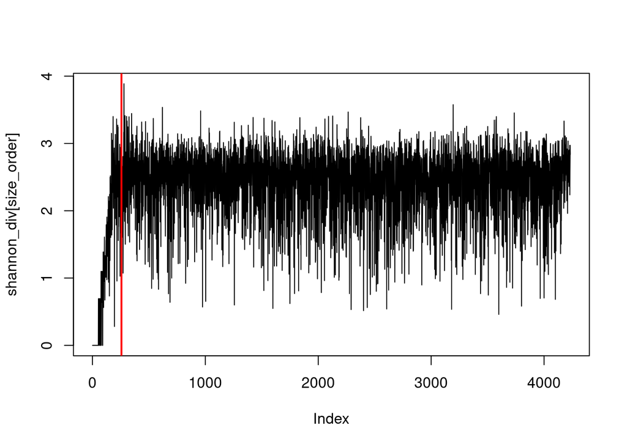

```r
  t_rownames<- rownames(tdata)
  tdata<- lapply(tdata, as.numeric) %>% as.data.frame()
  rownames(tdata)<- t_rownames
  lib_sizes<- rowSums(tdata)
  t_props<-( tdata
            )/lib_sizes #due to R recycling, each row gets divided by its sum
  shannon_div<- -rowSums((t_props+1e-10)*log(t_props+1e-10))
  simpson_index<- rowSums ( 1 - t_props^2  )
  inverse_simp<- 1/rowSums( t_props^2 )
  size_order<-order(lib_sizes)

  taxa_min_lib_size= 3636
  crit_rank= which.min(abs(lib_sizes[size_order] - taxa_min_lib_size))

  plot(shannon_div[size_order],type='l')
  abline(v = crit_rank, col="red",lwd=2)
```

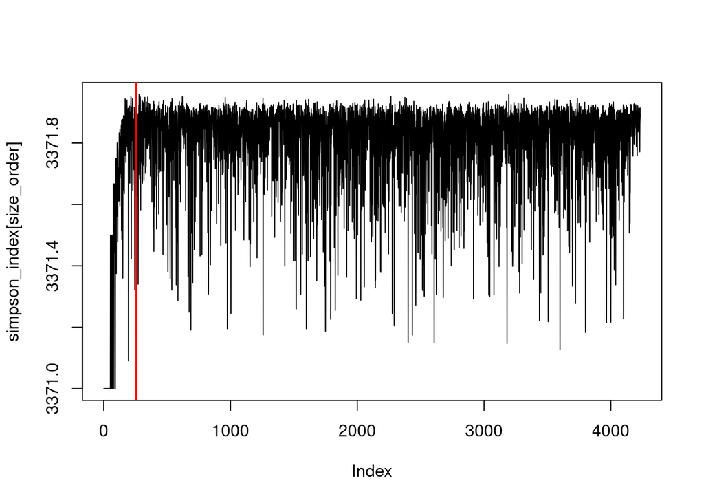

```r
  plot(simpson_index[size_order],type='l')
  abline(v = crit_rank, col="red",lwd=2)
```

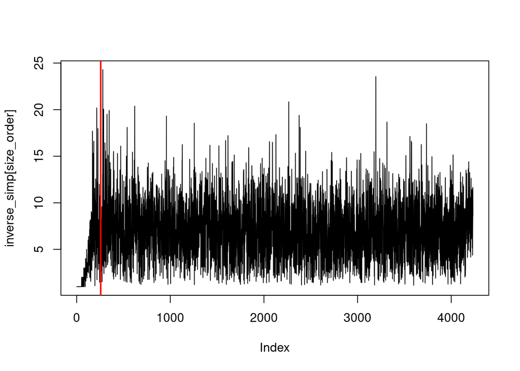

```r
  plot(inverse_simp[size_order],type='l')
  abline(v = crit_rank, col="red",lwd=2)
```

```r
  tdata<- tdata[ rowSums(tdata) >= taxa_min_lib_size, ]
  tdata<- tdata/rowSums(tdata)
```

### Integrate two types of information and prepare data for base resampling procedure

```r
common_names<- intersect(rownames(metadata), rownames(tdata))
tdata<- tdata[common_names,]
metadata<-metadata[common_names,]
print("# of samples left after filtering by alpha diversity (with repeating donors)")
```

```
[1] "# of samples left after filtering by alpha diversity (with repeating donors)"
```

```r
print(length(common_names))
```

```
[1] 3976
```

```r
print("# of unique donors")
```

```
[1] "# of unique donors"
```

```r
print(length(unique(metadata$host.subject.id)))
```

```
[1] 3670
```

## Median dataset and cohort summary

```r
y<- 1- metadata$allergic.to.i.have.no.food.allergies.that.i.know.of
names(y)<- rownames(metadata)

ids<-metadata$host.subject.id
names(ids)<-rownames(metadata)

donors<-unique(ids)

taxonomy.mean<-matrix(NA,length(donors),ncol(tdata))
rownames(taxonomy.mean)<-donors
colnames(taxonomy.mean)<-colnames(tdata)
meta.mean<-as.data.frame(matrix(NA,length(donors),6))
rownames(meta.mean)<-donors
colnames(meta.mean)<-c('age','sex','weight.kg','height.cm','BMI_cat','age_cat')
decision.mean<-numeric(length(donors))
names(decision.mean)<-donors

if (!file.exists("mean_data.RData")){
for (i in 1:length(donors)) {
 donor<-donors[i]
 samples<-names(ids)[ids==donor]

 #decision
 decs<-y[samples]
 decision.mean[i]<-floor(median(decs))

 #taxa
 taxa<-tdata[samples,,drop=F]
 taxonomy.mean[i,]<-colMedians(as.matrix(taxa))

 #metadata
 #age
 ages<-metadata[samples,'age.years']
 ages<-ages[!is.na(ages)]
 if (length(ages)>0) meta.mean[i,1]<-round(median(ages))
 #sex
 sexes<-metadata[samples,'sex']
 sexes<-sexes[!is.na(sexes)]
 if (length(sexes)>0) meta.mean[i,2]<-names(table(sexes))[which.max(table(sexes))]
 #weight
 weights<-as.numeric(metadata[samples,'weight.kg'])
 weights<-weights[!is.na(weights)]
 if (length(weights)>0) meta.mean[i,3]<-median(weights)
 #height
 heights<-as.numeric(metadata[samples,'height.cm'])
 heights<-heights[!is.na(heights)]
 if (length(heights)>0) meta.mean[i,4]<-median(heights)


 if(!((i-1)%%500)) print(sprintf("median data computation... %d / %d done",i, length(donors)))
}

mask.meta<-rowSums(is.na(meta.mean[,1:4]))==0

meta.mean.final<-meta.mean[mask.meta,]
meta.mean.final[meta.mean.final[1]<15,6]<-'0-14'
meta.mean.final[meta.mean.final[1]>=15 & meta.mean.final[1]<64,6]<-'15-64'
meta.mean.final[meta.mean.final[1]>=64,6]<-'65+'
bmi<-meta.mean.final[,'weight.kg']/meta.mean.final[,'height.cm']^2*10000
meta.mean.final[bmi<18.5,5]<-'Underweight'
meta.mean.final[bmi>=18.5 & bmi<25,5]<-'Normal'
meta.mean.final[bmi>=25 & bmi<30,5]<-'Overweight'
meta.mean.final[bmi>=30,5]<-'Obese'


decision.mean.final<-decision.mean[mask.meta]
taxonomy.mean.final<-taxonomy.mean[mask.meta,]
taxonomy.mean.final<-taxonomy.mean.final[,colSums(taxonomy.mean.final>0)>20]
taxonomy.mean.final<-as.data.frame(taxonomy.mean.final/rowSums(taxonomy.mean.final)*10000)

binary.mean.final<-taxonomy.mean.final*0
for (i in 1:ncol(binary.mean.final)) binary.mean.final[,i]<-taxonomy.mean.final[,i]>median(taxonomy.mean.final[,i])

save(meta.mean.final,decision.mean.final,taxonomy.mean.final,binary.mean.final,file='mean_data.RData')
} else {load("mean_data.RData")}


#Table 1
table(decision.mean.final)
```

```
decision.mean.final
   0    1
1704 1966
```

```r
table(meta.mean.final[decision.mean.final==0,2])
```

```
female   male
   906    798
```

```r
table(meta.mean.final[decision.mean.final==1,2])
```

```
female   male
  1091    875
```

```r
fisher.test(rbind(table(meta.mean.final[decision.mean.final==0,2]),
            table(meta.mean.final[decision.mean.final==1,2])))
```

```
    Fisher's Exact Test for Count Data

data:  rbind(table(meta.mean.final[decision.mean.final == 0, 2]), table(meta.mean.final[decision.mean.final == 1, 2]))
p-value = 0.1629
alternative hypothesis: true odds ratio is not equal to 1
95 percent confidence interval:
 0.797632 1.039528
sample estimates:
odds ratio
 0.9105843
```

```r
table(meta.mean.final[decision.mean.final==0,6])
```

```
 0-14 15-64   65+
   73  1331   300
```

```r
table(meta.mean.final[decision.mean.final==1,6])
```

```
 0-14 15-64   65+
  125  1552   289
```

```r
fisher.test(rbind(table(meta.mean.final[decision.mean.final==0,6]),
                  table(meta.mean.final[decision.mean.final==1,6])))#,simulate.p.value = T)
```

```
    Fisher's Exact Test for Count Data

data:  rbind(table(meta.mean.final[decision.mean.final == 0, 6]), table(meta.mean.final[decision.mean.final == 1, 6]))
p-value = 0.002245
alternative hypothesis: two.sided
```

```r
table(meta.mean.final[decision.mean.final==0,5])
```

```
     Normal       Obese  Overweight Underweight
        997         167         406         134
```

```r
table(meta.mean.final[decision.mean.final==1,5])
```

```
     Normal       Obese  Overweight Underweight
       1083         287         404         192
```

```r
fisher.test(rbind(table(meta.mean.final[decision.mean.final==0,5]),
                  table(meta.mean.final[decision.mean.final==1,5])))
```

```
    Fisher's Exact Test for Count Data

data:  rbind(table(meta.mean.final[decision.mean.final == 0, 5]), table(meta.mean.final[decision.mean.final == 1, 5]))
p-value = 5.216e-06
alternative hypothesis: two.sided
```

###Median dataset MDFS for reference

```r
source("FS_functions.R")
global_MDFS<-MDFS_FS(X= taxonomy.mean.final,
        y= decision.mean.final,lvl = 0.05,seed = 123,mc=30  )
global_U<- U_test_FS(X=taxonomy.mean.final, y=decision.mean.final, lvl=0.05, min_presence=30)
```

## Subsampling

`subsamample_donors` randomly splits donors into two groups - “keep” set and “leave out” group. for each of the donors, one sample is picked at random (some donors have sent more than one sample). Loop repeats this 500 times.

For each of the repeats, we store the sample indicator vector (`keep` vs `leave` out group, according to the index in original data).

```r
source("subsample_nonrepeating_donors.R")
host_id<- metadata$host.subject.id
names(host_id)<- rownames(metadata)
subsample<-list()
n_repeats=500
if (!file.exists("agp_subsamples63.rds")){
for (i in 1:n_repeats){
  set.seed(i)
  subsample_donors(taxonomy=tdata, disease=y,
                   host_id=host_id,
                   subsampleSize = 0.63,
                   print_summary = FALSE
                   )-> subsample[[i]]
if (i%% 50==0) message(sprintf("%d/500 done",i))
}
  invisible()
saveRDS(subsample, "agp_subsamples63.rds")
} else {
  subsample<-readRDS("agp_subsamples63.rds")
}
```

## Feature selection

### MDFS

Perform discrete variant of MDFS in 1D and 2D mode on each of the prepared base resamples.

whole procedure from discretization up to feature selection is encapsulated in one function `MDFS_FS`, that performs discrete version of MDFS in 2D and 1D on either of the binarization methods (by zero `0` or by median `m`). Respective results are stored in the sublists:

- `res_1D0`, `res_2D0`, `res_2Dm`, `res_1Dm`.

Results include also a set of “synergistic partners” - taxa that were found to contribute to the information gain of other taxa relevant in 2D analysis, but not relevant by themselves. For practical pruposes, we limit this set by thresholding on increase of IG of the taxa the pure partners were found relevant with, as we go from 1D to 2D statistic. Specifically, we report only those that had increased IG of their 2D relevant partners by at least the minimum value of 1D IG observed among the taxa relevant in 1D.

### U-test

Similar wrapper was prepared for Wilcoxon’s test (`U_test_FS` function). Obviously, we do not have any 2D interactions here.

### Resampling validation

We validate the results of feature selection by multiple repeats (500) of leave x% out subsampling (jackknife). For each of the subsampled datasets $\mathbf{X^*}, y^*$, where $\mathbf{X^*}$ are taxa abundances and $y^*$ is the disease status of interest, we perform U-test and MDFS based feature selection. The taxa from the selection procedure are then used to train the random forest classifiers, which are then evaluated on left out data (from this specific realisation of subsampling).

For MDFS analysis, we compare 3 sets of features per repeat:

- variables relevant in 1D only,
- relevant in 2D and 1D,
- relevant in 1D and 2D + synergistic partners.

We say here that a feature is relevant if it was found by a test based on either of discretization methods, by median or by zero.

Below code executes the validation for both of the procedures (takes around 6h to evaluate). Detailed steps of MDFS pipeline implemented in `MDFS_FS()` function are described later, using one example repeat of the validation.

```r
subsample<- readRDS("agp_subsamples63.rds")
n_repeats=500
source("FS_functions.R")
features_file_string="features/agp_features_selected_lop=%.2f.rds"
lop= 0.37 #leave out percentage

#if feature selection was not performed yet, set up the lists
fs_fname=sprintf(features_file_string,lop)
if (!file.exists(fs_fname)) {
features<- list(md1D=list(),
                md12D=list(),
                md12Dp=list(),
                u=list()
                )

} else { # otherwise load the saved result
  features<-readRDS(fs_fname)
}

set.seed(123)
seeds= sample.int(234234,n_repeats)

fs_j_pattern="features/agp_fs_set_j=%d_lop=%.2f.rds"
 full_MDFSres<- full_Ures<-list()
for (j in 1:n_repeats){
  fs_j_fname= sprintf(fs_j_pattern,j,lop)
  if(!file.exists(fs_j_fname)){
    message(fs_j_fname)
      set.seed(seeds[[j]])
      MDFS_FS(X= tdata[ subsample[[j]]$keep, ],
              y= y[ subsample[[j]]$keep ], lvl=0.05, p.adjust.method = "holm",
              seed= seeds[[j]],
              mc=30 #minimum allowed class size of binarized taxa abundance
              )-> all_mdfs_j
      U_test_FS(X=tdata[ subsample[[j]]$keep, ],
                y = y[ subsample[[j]]$keep ],
                lvl = 0.05,
                p.adjust.method = "holm",
                min_presence=30)->u_j
      fs_j=list(mdfs=all_mdfs_j, u=u_j)
      saveRDS(fs_j, fs_j_fname)
      } else {
        fs_j=readRDS(fs_j_fname)
        all_mdfs_j=fs_j$mdfs
        u_j=fs_j$u
  }

  full_MDFSres[[j]]=all_mdfs_j
  full_Ures[[j]]=u_j
  if  (!file.exists(features_file_string)) {
            features$u[[j]]=u_j$rel_set
            features$md1D[[j]]=union(all_mdfs_j$res_1Dm$rel_set, all_mdfs_j$res_1D0$rel_set)
            features$md12D[[j]]=Reduce(union, list(all_mdfs_j$res_2Dm$rel_set,
                                                  all_mdfs_j$res_2D0$rel_set,
                                                  features$md1D[[j]]))
            features$md12Dp[[j]]=Reduce(union, list(all_mdfs_j$res_2Dm$partner_set,
                                                  all_mdfs_j$res_2D0$partner_set,
                                                  features$md12D[[j]]))
          }
  model_file_string="RF_models/agp_j=%d_fs=%s_lop=%.2f.rds"
  for (fs_method in c(names(features),"md12DpInt" )){
    fname=sprintf(model_file_string,j,fs_method,lop)
    if (!file.exists(fname)){
        message(fname)
        set.seed(seeds[[j]])
      RF_fs_j=NA # set NA by default, immediately replaced by resulting model if
                 # fs_method found anything
      f_key<- if (fs_method=="md12DpInt") "md12Dp" else fs_method
      if (length(features[[f_key]][[j]])) {
      X_keep<-tdata[ subsample[[j]]$keep, ,
                                      drop=FALSE
                                      ]
      X_keep_sel<- X_keep[, features[[f_key]][[j]], drop=FALSE]
      X_rf<- X_keep_sel
      if (fs_method=="md12DpInt")
      {
              #if any true synergies were found, interaction_data has length == 4
              if (length(full_MDFSres[[j]]$res_2Dm$interaction_data)>1){
                    interaction_xm<- generate_interaction_variables(X_keep, full_MDFSres[[j]]$res_2Dm$interaction_data)
                    X_rf<- cbind(X_rf, interaction_xm)
              }
                if (length(full_MDFSres[[j]]$res_2D0$interaction_data)>1) {
                  interaction_x0<- generate_interaction_variables(X_keep, full_MDFSres[[j]]$res_2D0$interaction_data)
                  X_rf<- cbind(X_rf, interaction_x0)
              }
      }

      y_rf<-  y[   subsample[[j]]$keep ] |> as.factor()
      RF_fs_j= randomForest(x= X_rf,
                            y= y_rf)
      }

      saveRDS(RF_fs_j, file=fname)
    }

    #RF_models[[fs_method]][[j]]=RF_fs_j
  }

  message(sprintf("%d /%d done",j,n_repeats))

}
```

[output not shown]

[output not shown]

[output not shown]

[output not shown]

[output not shown]

[output not shown]

[output not shown]

[output not shown]

[output not shown]

[output not shown]

[output not shown]

[output not shown]

[output not shown]

[output not shown]

[output not shown]

[output not shown]

[output not shown]

[output not shown]

[output not shown]

[output not shown]

[output not shown]

[output not shown]

[output not shown]

[output not shown]

[output not shown]

[output not shown]

[output not shown]

[output not shown]

[output not shown]

[output not shown]

[output not shown]

[output not shown]

[output not shown]

[output not shown]

[output not shown]

[output not shown]

[output not shown]

[output not shown]

[output not shown]

[output not shown]

[output not shown]

[output not shown]

[output not shown]

[output not shown]

[output not shown]

[output not shown]

[output not shown]

[output not shown]

[output not shown]

[output not shown]

[output not shown]

[output not shown]

[output not shown]

[output not shown]

[output not shown]

[output not shown]

[output not shown]

[output not shown]

[output not shown]

[output not shown]

[output not shown]

[output not shown]

[output not shown]

[output not shown]

[output not shown]

[output not shown]

[output not shown]

[output not shown]

[output not shown]

[output not shown]

[output not shown]

[output not shown]

[output not shown]

[output not shown]

[output not shown]

[output not shown]

[output not shown]

[output not shown]

[output not shown]

[output not shown]

[output not shown]

[output not shown]

[output not shown]

[output not shown]

[output not shown]

[output not shown]

[output not shown]

[output not shown]

[output not shown]

[output not shown]

[output not shown]

[output not shown]

[output not shown]

[output not shown]

[output not shown]

[output not shown]

[output not shown]

[output not shown]

[output not shown]

[output not shown]

[output not shown]

[output not shown]

[output not shown]

[output not shown]

[output not shown]

[output not shown]

[output not shown]

[output not shown]

[output not shown]

[output not shown]

[output not shown]

[output not shown]

[output not shown]

[output not shown]

[output not shown]

[output not shown]

[output not shown]

[output not shown]

[output not shown]

[output not shown]

[output not shown]

[output not shown]

[output not shown]

[output not shown]

[output not shown]

[output not shown]

[output not shown]

[output not shown]

[output not shown]

[output not shown]

[output not shown]

[output not shown]

[output not shown]

[output not shown]

[output not shown]

[output not shown]

[output not shown]

[output not shown]

[output not shown]

[output not shown]

[output not shown]

[output not shown]

[output not shown]

[output not shown]

[output not shown]

[output not shown]

[output not shown]

[output not shown]

[output not shown]

[output not shown]

[output not shown]

[output not shown]

[output not shown]

[output not shown]

[output not shown]

[output not shown]

[output not shown]

[output not shown]

[output not shown]

[output not shown]

[output not shown]

[output not shown]

[output not shown]

[output not shown]

[output not shown]

[output not shown]

[output not shown]

[output not shown]

[output not shown]

[output not shown]

[output not shown]

[output not shown]

[output not shown]

[output not shown]

[output not shown]

[output not shown]

[output not shown]

[output not shown]

[output not shown]

[output not shown]

[output not shown]

[output not shown]

[output not shown]

[output not shown]

[output not shown]

[output not shown]

[output not shown]

[output not shown]

[output not shown]

[output not shown]

[output not shown]

[output not shown]

[output not shown]

[output not shown]

[output not shown]

[output not shown]

[output not shown]

[output not shown]

[output not shown]

[output not shown]

[output not shown]

[output not shown]

[output not shown]

[output not shown]

[output not shown]

[output not shown]

[output not shown]

[output not shown]

[output not shown]

[output not shown]

[output not shown]

[output not shown]

[output not shown]

[output not shown]

[output not shown]

[output not shown]

[output not shown]

[output not shown]

[output not shown]

[output not shown]

[output not shown]

[output not shown]

[output not shown]

[output not shown]

[output not shown]

[output not shown]

[output not shown]

[output not shown]

[output not shown]

[output not shown]

[output not shown]

[output not shown]

[output not shown]

[output not shown]

[output not shown]

[output not shown]

[output not shown]

[output not shown]

[output not shown]

[output not shown]

[output not shown]

[output not shown]

[output not shown]

[output not shown]

[output not shown]

[output not shown]

[output not shown]

[output not shown]

[output not shown]

[output not shown]

[output not shown]

[output not shown]

[output not shown]

[output not shown]

[output not shown]

[output not shown]

[output not shown]

[output not shown]

[output not shown]

[output not shown]

[output not shown]

[output not shown]

[output not shown]

[output not shown]

[output not shown]

[output not shown]

[output not shown]

[output not shown]

[output not shown]

[output not shown]

[output not shown]

[output not shown]

[output not shown]

[output not shown]

[output not shown]

[output not shown]

[output not shown]

[output not shown]

[output not shown]

[output not shown]

[output not shown]

[output not shown]

[output not shown]

[output not shown]

[output not shown]

[output not shown]

[output not shown]

[output not shown]

[output not shown]

[output not shown]

[output not shown]

[output not shown]

[output not shown]

[output not shown]

[output not shown]

[output not shown]

[output not shown]

[output not shown]

[output not shown]

[output not shown]

[output not shown]

[output not shown]

[output not shown]

[output not shown]

[output not shown]

[output not shown]

[output not shown]

[output not shown]

[output not shown]

[output not shown]

[output not shown]

[output not shown]

[output not shown]

[output not shown]

[output not shown]

[output not shown]

[output not shown]

[output not shown]

[output not shown]

[output not shown]

[output not shown]

[output not shown]

[output not shown]

[output not shown]

[output not shown]

[output not shown]

[output not shown]

[output not shown]

[output not shown]

[output not shown]

[output not shown]

[output not shown]

[output not shown]

[output not shown]

[output not shown]

[output not shown]

[output not shown]

[output not shown]

[output not shown]

[output not shown]

[output not shown]

[output not shown]

[output not shown]

[output not shown]

[output not shown]

[output not shown]

[output not shown]

[output not shown]

[output not shown]

[output not shown]

[output not shown]

[output not shown]

[output not shown]

[output not shown]

[output not shown]

[output not shown]

[output not shown]

[output not shown]

[output not shown]

[output not shown]

[output not shown]

[output not shown]

[output not shown]

[output not shown]

[output not shown]

[output not shown]

[output not shown]

[output not shown]

[output not shown]

[output not shown]

[output not shown]

[output not shown]

[output not shown]

[output not shown]

[output not shown]

[output not shown]

[output not shown]

[output not shown]

[output not shown]

[output not shown]

[output not shown]

[output not shown]

[output not shown]

[output not shown]

[output not shown]

[output not shown]

[output not shown]

[output not shown]

[output not shown]

[output not shown]

[output not shown]

[output not shown]

[output not shown]

[output not shown]

[output not shown]

[output not shown]

[output not shown]

[output not shown]

[output not shown]

[output not shown]

[output not shown]

[output not shown]

[output not shown]

[output not shown]

[output not shown]

[output not shown]

[output not shown]

[output not shown]

[output not shown]

[output not shown]

[output not shown]

[output not shown]

[output not shown]

[output not shown]

[output not shown]

[output not shown]

[output not shown]

[output not shown]

[output not shown]

[output not shown]

[output not shown]

[output not shown]

[output not shown]

[output not shown]

[output not shown]

[output not shown]

[output not shown]

[output not shown]

[output not shown]

[output not shown]

[output not shown]

[output not shown]

[output not shown]

[output not shown]

[output not shown]

[output not shown]

[output not shown]

[output not shown]

[output not shown]

[output not shown]

[output not shown]

[output not shown]

[output not shown]

[output not shown]

[output not shown]

[output not shown]

[output not shown]

[output not shown]

[output not shown]

[output not shown]

[output not shown]

[output not shown]

[output not shown]

[output not shown]

[output not shown]

[output not shown]

[output not shown]

[output not shown]

[output not shown]

[output not shown]

[output not shown]

[output not shown]

[output not shown]

[output not shown]

[output not shown]

[output not shown]

[output not shown]

[output not shown]

[output not shown]

[output not shown]

[output not shown]

[output not shown]

[output not shown]

[output not shown]

[output not shown]

[output not shown]

[output not shown]

[output not shown]

[output not shown]

[output not shown]

[output not shown]

[output not shown]

[output not shown]

[output not shown]

[output not shown]

[output not shown]

[output not shown]

[output not shown]

[output not shown]

[output not shown]

[output not shown]

[output not shown]

[output not shown]

[output not shown]

[output not shown]

[output not shown]

[output not shown]

[output not shown]

[output not shown]

[output not shown]

```r
n_repeats=500
#n_repeats=30
source("balanced_decision.R")
METHODS=c(names(features))
METRICS=c("AUC","OR")
odds_ratio<- function(y_pred, y){
 # if(length(unique(y_pred))<2){
    #print(sprintf("bad table %s %s",method, cohort));
  #  return(1)}
  stopifnot(length(unique(y))==2)
  CM= matrix(nrow=2,ncol=2)
  CM[1,1]=sum( (y_pred==0) & (y==0))
  CM[2,1]=sum( (y_pred==1) & (y==0))
  CM[1,2]=sum( (y_pred==0) & (y==1))
  CM[2,2]=sum( (y_pred==1) & (y==1))
  if (any(CM==0)) CM= CM + 1
  (CM[2,2]*CM[1,1])/(CM[1,2]*CM[2,1])
}
if (!file.exists("performance_agp.rds")) {
performance=array(dim = c(length(METHODS),length(METRICS), n_repeats),
                  dimnames = list(
                                  METHODS,
                                  METRICS,
                                  NULL  #500 repeats
                                  )
                  )

pred_thr= array(NA, dim= c( length(METHODS),n_repeats),
                 dimnames = list(
                                  METHODS,
                                  NULL  #500 repeats
                                  )
)

for (j in 1:n_repeats){
  for (method in METHODS){
    fname=sprintf(model_file_string,j,method,lop)
  RF_mj<- readRDS(fname)
  no_features<- (length(RF_mj)==1)
    if (no_features){
      print(sprintf("null %s %s",method))
      performance[method,"AUC",j]=0.5
      performance[method,"OR",j]=1
    } else {
    f_key= if (method %in% names(features)) method else "md12Dp"
    X_test<- tdata[ subsample[[j]]$leave, ,drop=FALSE]
    X_rf<- X_test[, features[[f_key]][[j]], drop=FALSE ]
    if (method=="md12DpInt"){
      if (length(full_MDFSres[[j]]$res_2Dm$interaction_data)>1){
                    interaction_xm<- generate_interaction_variables(X_test, full_MDFSres[[j]]$res_2Dm$interaction_data)
                    X_rf<- cbind(X_rf, interaction_xm)
              }
      if (length(full_MDFSres[[j]]$res_2D0$interaction_data)>1){
                    interaction_x0<- generate_interaction_variables(X_test, full_MDFSres[[j]]$res_2D0$interaction_data)
                    X_rf<- cbind(X_rf, interaction_x0)
      }
    X_rf_ref<-X_rf
    }
    test_pred= predict(RF_mj, newdata=  X_rf,
                      type="prob"  )[,2]
    y_thr= balanced.decision(x = RF_mj$votes[,2],
                             y= y[   subsample[[j]]$keep ] )$threshold
    pred_thr[method,j]=y_thr
    y_pbin<- (test_pred >= y_thr)
    confusion=table(Predicted=y_pbin,Actual= y[   subsample[[j]]$leave ] )
    performance[method,"AUC",j]= auc(response=y[   subsample[[j]]$leave ],
                                        predictor=test_pred,quiet=TRUE)|> as.numeric()
    performance[method,"OR",j]=  odds_ratio(y_pbin, y[   subsample[[j]]$leave ])

    }
  }
  j_= j-1
  if (j_==0) message(paste0(rep("_",n_repeats %/% 10),collapse=""))
  if ((j_>0) && (j_ %% 10 == 0)) cat("#")
}

} else {
  performance<-readRDS("performance_agp.rds")
}
```

##### Overall performance (median dataset ROC curve)

```r
METHODxROC=list()
AUCxROC=list()
CONFxMETHOD=list()
ORxMETHOD=list()

set.seed(644545)
seeds_glob=sample.int(213212,4,replace=FALSE)
names(seeds_glob)= METHODS[1:4]
for (METHOD in METHODS[1:4]){
if (METHOD=='u') sel_feats<- global_U$rel_set
if (METHOD=='md1D') sel_feats<- union(global_MDFS$res_1Dm$rel_set,
                    global_MDFS$res_1D0$rel_set)
if (METHOD=='md12D') sel_feats<- Reduce(union, list(global_MDFS$res_2Dm$rel_set,
                    global_MDFS$res_1Dm$rel_set,
                    global_MDFS$res_1D0$rel_set,
                    global_MDFS$res_2D0$rel_set))
if (METHOD=='md12Dp') sel_feats<- Reduce(union,list(global_MDFS$res_2Dm$rel_set,
                    global_MDFS$res_1Dm$rel_set,
                    global_MDFS$res_1D0$rel_set,
                    global_MDFS$res_2D0$rel_set,
                    global_MDFS$res_2D0$partner_set,
                    global_MDFS$res_2Dm$partner_set
                    ))

set.seed(seeds_glob[[METHOD]])
RF_mdl<- randomForest(x=taxonomy.mean.final[,sel_feats],
              y= decision.mean.final |> as.factor() )
    y_thr= balanced.decision(x = RF_mdl$votes[,2],
                             y= decision.mean.final )$threshold
    y_pbin<- (RF_mdl$votes[,2] >= y_thr)
    CONFxMETHOD[[METHOD]]=table(Predicted=as.numeric(y_pbin),Actual= decision.mean.final)
    ORxMETHOD[[METHOD]]=odds_ratio(y_pred = y_pbin,y = decision.mean.final)
    roc_curve=roc(response=decision.mean.final,
        predictor=RF_mdl$votes[,2],quiet=TRUE)
METHODxROC[[METHOD]]= roc_curve
AUCxROC[[METHOD]]= auc(roc_curve)
}
names(METHODxROC)<- c("MDFS-1D","MDFS-2D", "MDFS-2D + partners", "U-test")

for (i_nm in seq_along(names(METHODxROC)))
  for (i_nm2 in seq_along(names(METHODxROC)))
    if (i_nm<i_nm2) { nm<- names(METHODxROC)[[i_nm]]; nm2<- names(METHODxROC)[[i_nm2]]
      print(sprintf("%s vs %s", nm,nm2))
    print(roc.test(METHODxROC[[nm]], METHODxROC[[nm2]]))
    }
```

```
[1] "MDFS-1D vs MDFS-2D"

    DeLong's test for two correlated ROC curves

data:  METHODxROC[[nm]] and METHODxROC[[nm2]]
Z = -2.806, p-value = 0.005017
alternative hypothesis: true difference in AUC is not equal to 0
95 percent confidence interval:
 -0.018854541 -0.003346826
sample estimates:
AUC of roc1 AUC of roc2
  0.7234278   0.7345285

[1] "MDFS-1D vs MDFS-2D + partners"

    DeLong's test for two correlated ROC curves

data:  METHODxROC[[nm]] and METHODxROC[[nm2]]
Z = -3.5414, p-value = 0.000398
alternative hypothesis: true difference in AUC is not equal to 0
95 percent confidence interval:
 -0.023027561 -0.006619634
sample estimates:
AUC of roc1 AUC of roc2
  0.7234278   0.7382514

[1] "MDFS-1D vs U-test"

    DeLong's test for two correlated ROC curves

data:  METHODxROC[[nm]] and METHODxROC[[nm2]]
Z = 0.74289, p-value = 0.4575
alternative hypothesis: true difference in AUC is not equal to 0
95 percent confidence interval:
 -0.004728925  0.010501949
sample estimates:
AUC of roc1 AUC of roc2
  0.7234278   0.7205413

[1] "MDFS-2D vs MDFS-2D + partners"
```

[output cut: 22 more lines]

```
AUC of roc1 AUC of roc2
  0.7345285   0.7205413

[1] "MDFS-2D + partners vs U-test"

    DeLong's test for two correlated ROC curves

data:  METHODxROC[[nm]] and METHODxROC[[nm2]]
Z = 3.7533, p-value = 0.0001745
alternative hypothesis: true difference in AUC is not equal to 0
95 percent confidence interval:
 0.008461945 0.026958273
sample estimates:
AUC of roc1 AUC of roc2
  0.7382514   0.7205413
```

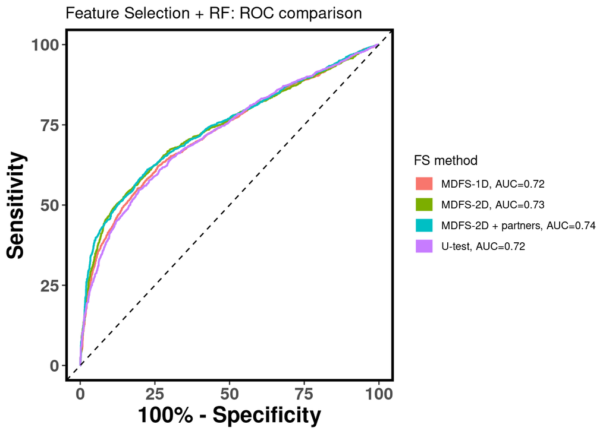

```r
names(METHODxROC)<- sapply(seq_along(METHODxROC),
                           function(m)
                             sprintf("%s, AUC=%.2f",
                                     names(METHODxROC)[[m]],
                                     AUCxROC[[m]]))

#pdf("roc_curve_v2.pdf", width=8,height=5)
ggroc(METHODxROC, legacy.axes = T,aes=c("color"),lwd=0.75) +
geom_abline(slope = 1 ,intercept = 0, linetype="dashed") + # add identity line
theme(
panel.background = element_blank(),
axis.title.x = element_text(size =18, face = 'bold'),
axis.title.y = element_text(size =18, face = 'bold'),
panel.border = element_rect(size = 2, fill = NA),
axis.text.x = element_text(size = 14, face ='bold'),
axis.text.y = element_text(size = 14, face ='bold')) +
xlab('100% - Specificity') +
ylab('Sensitivity') +
scale_x_continuous(breaks = seq(0,1,0.25), labels = seq(0,1,0.25) * 100) +
scale_y_continuous(breaks = seq(0,1,0.25), labels = seq(0,1,0.25) * 100) +
  ggtitle("Feature Selection + RF: ROC comparison") +# theme(legend.position = "left")
  scale_color_discrete(name = "FS method") +
   guides(color = guide_legend(override.aes = list(lwd = 5)))
```

```r
for (m in METHODS[1:4]){
    print(m)
    print(CONFxMETHOD[[m]])
    print(sprintf("OR=%.3f ",ORxMETHOD[[m]]))
}
```

```
[1] "md1D"
         Actual
Predicted    0    1
        0 1080  620
        1  624 1346
[1] "OR=3.757 "
[1] "md12D"
         Actual
Predicted    0    1
        0 1105  597
        1  599 1369
[1] "OR=4.230 "
[1] "md12Dp"
         Actual
Predicted    0    1
        0 1101  602
        1  603 1364
[1] "OR=4.137 "
[1] "u"
         Actual
Predicted    0    1
        0 1078  622
        1  626 1344
[1] "OR=3.721 "
```

```r
#dev.off()
```

```r
#  model_file_string="RF_models/agp_j=%d_fs=%s_lop=%.2f.rds"
#global_MDFS<-MDFS_FS(X= taxonomy.mean.final,
#        y= decision.mean.final,lvl = 0.05,seed = 123,mc=30  )
#global_U<- U_test_FS(X=taxonomy.mean.final, y=decision.mean.final, lvl=0.05, min_presence=30)
#
#set.seed(644545)
#r=sample.int(n_repeats,size = 1)
#print(r)
#METHODxROC=list()
#AUCxROC=list()
#CONFxMETHOD=list()
#ORxMETHOD=list()
#for (METHOD in METHODS[1:4]){
#fname=sprintf(model_file_string,r,METHOD,lop)
#RF_mdl<- readRDS(fname)
#no_features<- (length(RF_mdl)==1)
#stopifnot(!no_features)
#    f_key= if (METHOD %in% names(features)) METHOD else "md12Dp"
#    X_test<- tdata[ subsample[[r]]$leave, ,drop=FALSE]
#    X_rf<- X_test[, features[[f_key]][[r]], drop=FALSE ]
#    test_pred= predict(RF_mdl, newdata=  X_rf,
#                      type="prob"  )[,2]
#    y_thr= balanced.decision(x = RF_mdl$votes[,2],
#                             y= y[   subsample[[r]]$keep ] )$threshold
#    y_pbin<- (test_pred >= y_thr)
#    CONFxMETHOD[[METHOD]]==table(Predicted=as.numeric(y_pbin),Actual= y[   subsample[[r]]$leave ] )
#    ORxMETHOD[[METHOD]]=odds_ratio(y_pred = y_pbin,y = y[ subsample[[r]]$leave])
#    roc_curve=roc(response=y[   subsample[[r]]$leave ],
#        predictor=test_pred,quiet=TRUE)
#METHODxROC[[METHOD]]= roc_curve
#AUCxROC[[METHOD]]= auc(roc_curve)
#}
#names(METHODxROC)<- c("MDFS-1D","MDFS-2D", "MDFS-2D + partners", "U-test")
#
#for (i_nm in seq_along(names(METHODxROC)))
#  for (i_nm2 in seq_along(names(METHODxROC)))
#    if (i_nm<i_nm2) { nm<- names(METHODxROC)[[i_nm]]; nm2<- names(METHODxROC)[[i_nm2]]
#      print(sprintf("%s vs %s", nm,nm2))
#    print(roc.test(METHODxROC[[nm]], METHODxROC[[nm2]]))
#    }
#names(METHODxROC)<- sapply(seq_along(METHODxROC),
#                           function(m)
#                             sprintf("%s, AUC=%.2f",
#                                     names(METHODxROC)[[m]],
#                                     AUCxROC[[m]]))
#
##pdf("roc_curve_v2.pdf", width=8,height=5)
#ggroc(METHODxROC, legacy.axes = T,aes=c("color"),lwd=0.75) +
#geom_abline(slope = 1 ,intercept = 0, linetype="dashed") + # add identity line
#theme(
#panel.background = element_blank(),
#axis.title.x = element_text(size =18, face = 'bold'),
#axis.title.y = element_text(size =18, face = 'bold'),
#panel.border = element_rect(size = 2, fill = NA),
#axis.text.x = element_text(size = 14, face ='bold'),
#axis.text.y = element_text(size = 14, face ='bold')) +
#xlab('100% - Specificity') +
#ylab('Sensitivity') +
#scale_x_continuous(breaks = seq(0,1,0.25), labels = seq(0,1,0.25) * 100) +
#scale_y_continuous(breaks = seq(0,1,0.25), labels = seq(0,1,0.25) * 100) +
#  ggtitle("Feature Selection + RF: ROC comparison") +# theme(legend.position = "left")
#  scale_color_discrete(name = "FS method") +
#   guides(color = guide_legend(override.aes = list(lwd = 5)))
##dev.off()
```

###### Synthetic variables test (chinese paper (doesnt work))

```r
#pairs<-rbind(
#cbind(full_MDFSres[[r]]$res_2Dm$interaction_data$rel_name,
#full_MDFSres[[r]]$res_2Dm$interaction_data$partner_name),
#cbind(full_MDFSres[[r]]$res_2D0$interaction_data$rel_name,
#full_MDFSres[[r]]$res_2D0$interaction_data$partner_name))
#METHOD="md12pInt"
#    f_key= if (METHOD %in% names(features)) METHOD else "md12Dp"
#    X_test<- tdata[ subsample[[r]]$leave, ,drop=FALSE]
#    X_train<- tdata[ subsample[[r]]$keep, ,drop=FALSE]
#    X_rf_train<- X_train[, features[[f_key]][[r]], drop=FALSE ]
#    X_rf_test<- X_test[, features[[f_key]][[r]], drop=FALSE ]
#synthetic_variables<- function(data, pairs, pairwise_fun){
# apply(pairs,1,function(ROW) pairwise_fun(rank(data[, ROW[[1]] ]), rank(data[, ROW[[2]] ])),
#       simplify=FALSE) |> as.data.frame()
#}
#S_trainPlus<-synthetic_variables(X_rf_train, pairs,function(x,y) x+y)
#S_trainDiff<-synthetic_variables(X_rf_train, pairs,function(x,y) x-y)
#S_trainProd<-synthetic_variables(X_rf_train, pairs,function(x,y) x*y)
#S_trainSgn<-synthetic_variables(X_rf_train, pairs,function(x,y)  x>y)
#S_trainAbs<-synthetic_variables(X_rf_train, pairs,function(x,y)  abs(x-y))
#X_rf_trainPlus<- cbind(X_rf_train,S_trainPlus)
#X_rf_trainDiff<- cbind(X_rf_train,S_trainDiff)
#X_rf_trainProd<- cbind(X_rf_train,S_trainProd)
#X_rf_trainSgn<- cbind(X_rf_train,S_trainSgn)
#X_rf_trainAbs<- cbind(X_rf_train,S_trainAbs)
#X_rf_trainAll<- cbind(X_rf_train, S_trainPlus,
#                      S_trainDiff,
#                      S_trainProd,
#                      S_trainSgn,
#                      S_trainAbs)
#message("rfs...")
#rf_plus<- randomForest(x= X_rf_trainPlus,
#                       y= y[ subsample[[r]]$keep ] |> as.factor() )
#cat("x")
#rf_diff<- randomForest(x= X_rf_trainDiff,
#                       y= y[ subsample[[r]]$keep ] |> as.factor() )
#cat("x")
#rf_prod<- randomForest(x= X_rf_trainProd,
#                       y= y[ subsample[[r]]$keep ] |> as.factor() )
#cat("x")
#rf_sgn<- randomForest(x= X_rf_trainSgn,
#                       y= y[ subsample[[r]]$keep ] |> as.factor())
#cat("x")
#rf_abs<- randomForest(x= X_rf_trainAbs,
#                       y= y[ subsample[[r]]$keep ] |> as.factor())
#cat("x")
#rf_all<- randomForest(x= X_rf_trainAll,
#                       y= y[ subsample[[r]]$keep ] |> as.factor())
#cat("x")
```

```r
#| label: synthetic_auc
#| dependson: synthetic
#| cache: true
#auc_from_rf<- function(rf,y_train){
# as.numeric( auc(response=y_train, predictor= rf$votes[,2]))
#}
#print("Synethetic models performace:")
#print(auc_from_rf(rf=rf_plus, y_train = y[ subsample[[r]]$keep ] ))
#print(auc_from_rf(rf=rf_diff, y_train = y[ subsample[[r]]$keep ] ))
#print(auc_from_rf(rf=rf_prod, y_train = y[ subsample[[r]]$keep ] ))
#print(auc_from_rf(rf=rf_sgn, y_train = y[ subsample[[r]]$keep ] ))
#print(auc_from_rf(rf=rf_abs, y_train = y[ subsample[[r]]$keep ] ))
#print(auc_from_rf(rf=rf_all, y_train = y[ subsample[[r]]$keep ] ))
#
```

###### Aggregate performance calculation and visualization

```r
if (!file.exists("performance_agp.rds")) saveRDS(performance, "performance_agp.rds")
```

```r
#install.packages("reshape2")
long_perf <- melt(performance,
                  varnames = c("Method", "Metric", "Repeat"), value.name = "Value")
```

```r
#install.packages("dplyr")
```

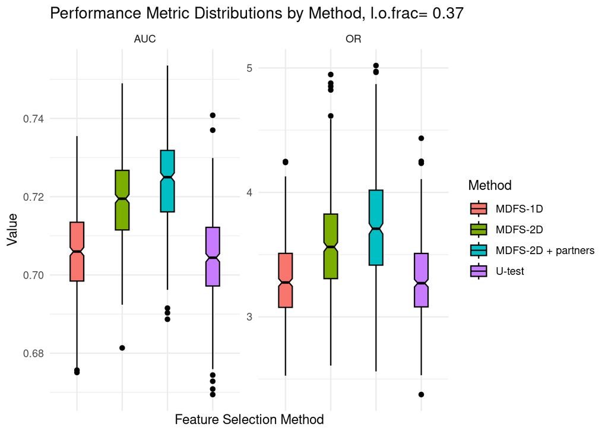

```r
#install.packages("ggplot2")
#summary_lines <- long_perf %>%
#  group_by(Metric, Method) %>%
#  summarise(
#    median = median(Value),
#    notch_lower = quantile(Value, 0.25) + 1.57 * IQR(Value) / sqrt(n()),
#    notch_upper = quantile(Value, 0.75) - 1.57 * IQR(Value) / sqrt(n()),
#    .groups = "drop"
#  )
levels(long_perf$Method) <- c("MDFS-1D", "MDFS-2D", "MDFS-2D + partners", "U-test", "md12DpInt")

# Violin plot to show distribution
ggplot(long_perf[long_perf$Method!="md12DpInt",], aes(x = Method, y = Value, fill = Method)) +
  #geom_violin(trim = FALSE, alpha = 0.7) +
  geom_boxplot(width = 0.3, color = "black", notch = TRUE) +
   #geom_hline(data = summary_lines, aes(yintercept = median, color = Method), linetype = "solid") +

  # Add dashed lines for notches
#  geom_hline(data = summary_lines, aes(yintercept = notch_lower, color = Method), linetype = "dashed") +
 # geom_hline(data = summary_lines, aes(yintercept = notch_upper, color = Method), linetype = "dashed") +
  facet_wrap(~ Metric, scales = "free_y") +  # Separate plots for AUC and OR
  #theme_minimal() +
  labs(title = sprintf("Performance Metric Distributions by Method, l.o.frac= %.2f",lop),
       y = "Value", x = "Feature Selection Method") + theme_minimal()+
  theme(legend.position = "right", axis.text.x = element_blank(), axis.ticks.x = element_blank())
```

###### Selection & partnership frequency calculation and visualization

```r
universe<- colnames(tdata)

do.call(rbind,
        lapply(features, function(method_repeats)
            Reduce("+", lapply(method_repeats, function(one_repeat_of_a_method)
                                                    universe %in% one_repeat_of_a_method
                                                    ),
                )
            )
        )-> feature_absence_presence

colnames(feature_absence_presence)<-universe

frequent_<- list(over95= .95*n_repeats, over90=.9*n_repeats)
feature_absence_presence[, colAnys(feature_absence_presence >= frequent_$over95)] -> features_AP_filtered95
feature_absence_presence[, colAnys(feature_absence_presence >= frequent_$over90)] -> features_AP_filtered90
```

```r
viz_f90<- features_AP_filtered90
colnames(viz_f90)<- sapply(strsplit(colnames(viz_f90),split="\\."), function(x) x[[length(x)]])
viz_f90<-t(viz_f90) |> as.data.frame()
viz_f90[ do.call(order, viz_f90),]
```

```
                           md1D md12D md12Dp   u
g__Lautropia                  0    83    459   0
o__Pasteurellales             0   166    458   0
g__Gemella                    0   275    500   0
f__Fusobacteriaceae           0   355    496   0
g__Capnocytophaga             0   404    500   0
g__Leptotrichia               0   418    500   0
g__Granulicatella             0   434    499   0
f__Pasteurellaceae            0   451    500   0
p__candidate_division_CPR1    0   469    500   0
g__Bergeyella                 0   500    500   0
g__Aliivibrio                45   397    493  13
g__Streptococcus             48   469    500   1
g__Haemophilus              127   251    472   0
g__Porphyromonas            141   420    481   2
g__Fusobacterium            159   482    498  16
f__Bifidobacteriaceae       418   433    433 473
g__Robinsoniella            455   456    456 382
o__Bacillales               461   470    470 253
s__Collinsella_aerofaciens  461   476    477 463
f__Sphingomonadaceae        465   470    470 396
g__Bifidobacterium          468   471    471 470
g__Paucibacter              475   477    479 411
g__Sphingomonas             488   490    490 435
g__Lawsonella               490   499    499 461
f__Chitinophagaceae         498   498    498 489
f__Corynebacteriaceae       499   499    499 442
g__Xanthomonas              499   499    499 497
g__Chryseobacterium         500   500    500 499
g__Cutibacterium            500   500    500 500
g__Staphylococcus           500   500    500 500
f__Streptococcaceae         500   500    500 500
f__Neisseriaceae            500   500    500 500
g__Neisseria                500   500    500 500
g__Pseudomonas              500   500    500 500
```

```r
# mean IG = mean over all repeats
# IG in repeat= max IG (median-discretized, zero-discretized)
# partner in repeat= one with synergy
#       if both zero and median are synergistic - arg max (IG)
#overall partner - most frequent
#only partners - overall partners but not in 1D or 2D relevant set 90% of times.
plausible<- colnames(features_AP_filtered90)

stopifnot(  #code below works if all taxa in the set plausible taxo were present in each of the
            #subsamples (might dissapear due to filtering out of sparse columns)
            #this condition catches this unlikely exception
all(sapply(full_MDFSres, function(mdfs)
              sapply(mdfs, function(x)
                  plausible %in% x$feature_names
                )
))
)
rel_2D<-
presence_mD<-presence_0D<-abundance_per_repD<-
presence_mH<-presence_0H<-abundance_per_repH<-
presence_m<-presence_0<-abundance_per_rep<-
IG1D<-IG2D<- matrix(nrow=n_repeats, ncol=length(plausible))

partners_m0<-partners_0<-partners_m<- matrix(0,nrow=length(plausible), ncol=ncol(tdata))

for (j in c(1:n_repeats) ){
  mdfs_j<- full_MDFSres[[j]]
  for (k in seq_along(mdfs_j)) names(mdfs_j[[k]]$statistic)<- mdfs_j[[k]]$feature_names

  rel_2D[j,]= plausible %in% union(mdfs_j$res_2Dm$rel_set,
                                   mdfs_j$res_2D0$rel_set
                                   )

  plaus_IG1Dm<- mdfs_j$res_1Dm$statistic[plausible]
  plaus_IG1D0<- mdfs_j$res_1D0$statistic[plausible]
  plaus_IG2Dm<- mdfs_j$res_2Dm$statistic[plausible]
  plaus_IG2D0<- mdfs_j$res_2D0$statistic[plausible]
  IG1D[j,]<- pmax(plaus_IG1Dm,plaus_IG1D0)
  mIG2D_bigger<- plaus_IG2Dm>plaus_IG2D0
  IG2D[j,]<- pmax(plaus_IG2Dm,plaus_IG2D0)

  full_MDFSres[[1]]$res_2D0$partner_df[full_MDFSres[[1]]$res_2D0$partner_df$rel_name %in% plausible,]
  pm0j<-pmj<-p0j<- matrix(nrow=length(plausible), ncol=ncol(tdata))
  for (i_p in seq_along(plausible)){
    pmj[i_p,]= colnames(tdata) %in%  mdfs_j$res_2Dm$partner_df[ mdfs_j$res_2Dm$partner_df$rel_name== plausible[[i_p]], ]$partner_name
    p0j[i_p,]= colnames(tdata) %in%  mdfs_j$res_2D0$partner_df[ mdfs_j$res_2D0$partner_df$rel_name== plausible[[i_p]], ]$partner_name
    pm0j[i_p,]= p0j[i_p,] | pmj[i_p,]
  }
  partners_0<- partners_0 + p0j
  partners_m<- partners_m + pmj
  partners_m0<- partners_m0 + pm0j

  #partners_0<- mdfs_j$res_2D0$partner_df
  #partners_m<- mdfs_j$res_2Dm$partner_df
  #partners_0<- partners_0[partners_0$synergy,]  #only those which are truly synergistic
  #partners_m<- partners_m[partners_m$synergy,]
  #rownames(partners_0)<-partners_0$rel_name     #to make it possible to select by rows
  #rownames(partners_m)<-partners_m$rel_name     # see partner_j filling
  #has_partner<- plausible %in% union(partners_0$rel_name, partners_m$rel_name)
  #partner_j<- rep(NA, length(plausible))
  #for each of the taxa that had a partner at j-th rep,
  #if median based IG was bigger, use partner from partners_m,otherwise from partners_0
  #partner_j[has_partner]<- ifelse(mIG2D_bigger[has_partner],
  #                                partners_m[plausible[has_partner],]$partner_name,
  #                                partners_0[plausible[has_partner],]$partner_name
  #                                )
  #partners_per_rep[j,]=partner_j

  #mean abundance & presence

  plausible_ab_at_j<-tdata[ subsample[[j]]$keep, plausible ]
  presence_m_at_j<-binarize_taxa(as.matrix(plausible_ab_at_j),
                thresholds = colMedians(as.matrix(plausible_ab_at_j)) )
  presence_0_at_j<-binarize_taxa(as.matrix(plausible_ab_at_j),
                thresholds = rep(0, ncol(plausible_ab_at_j)))
  abundance_per_rep[j,]= colMeans(plausible_ab_at_j)
  presence_0[j,]=  colMeans(presence_0_at_j)
  presence_m[j,]=  colMeans(presence_m_at_j)
  abundance_per_repH[j,]=colMeans(plausible_ab_at_j[y[subsample[[j]]$keep]==0, ])
  abundance_per_repD[j,]=colMeans(plausible_ab_at_j[y[subsample[[j]]$keep]==1, ])
  presence_0H[j,]=colMeans(presence_0_at_j[y[subsample[[j]]$keep]==0, ])
  presence_0D[j,]=colMeans(presence_0_at_j[y[subsample[[j]]$keep]==1, ])
  presence_mH[j,]=colMeans(presence_m_at_j[y[subsample[[j]]$keep]==0, ])
  presence_mD[j,]=colMeans(presence_m_at_j[y[subsample[[j]]$keep]==1, ])
  if ((j-1) %%100==0) message(sprintf("%d/%d",j,n_repeats))
}
```

```
1/500
```

```
101/500
```

```
201/500
```

```
301/500
```

```
401/500
```

```r
rel_2D_named<- rel_2D
colnames(rel_2D_named)<- sapply(strsplit(plausible, "\\."), function(x) x[[length(x)]])
freqs_pure2D<- colSums(rel_2D_named)
freqs_1or2D<- viz_f90$md12D
vpm0<- partners_m0
colnames(vpm0)<- sapply(strsplit(colnames(tdata), "\\."), function(x) x[[length(x)]])
rownames(vpm0)<-sapply(strsplit(plausible, "\\."), function(x) x[[length(x)]])
cbind(rel2D_freq=freqs_pure2D,
      rel12D_freq=freqs_1or2D,
      vpm0[, colMaxs(vpm0)>= 200])-> freq_and_partners
freq_and_partners<- freq_and_partners[ freq_and_partners[, "rel12D_freq"] > 400, ]
write.csv(freq_and_partners, file= "agp_2D_rel_freq&partnerships.csv")
```

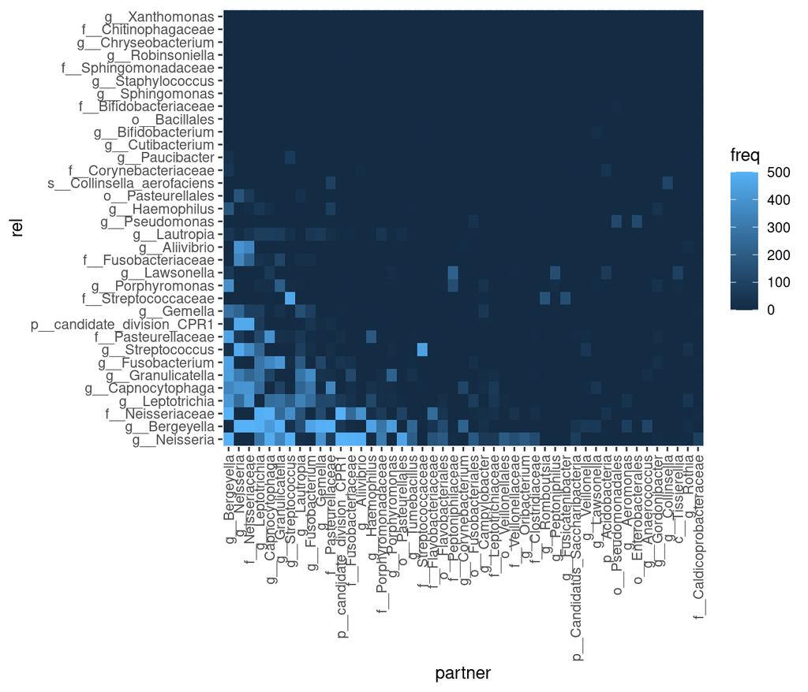

```r
vpm0<- vpm0[,order(colSums(vpm0),decreasing=TRUE)]
vpm0<- vpm0[order(rowSums(vpm0), decreasing = TRUE),]
vpm0<- vpm0[, colSums(vpm0)>100]

vpm0_flat<-melt(vpm0)
colnames(vpm0_flat)<-c("rel","partner","freq")
ggplot(vpm0_flat, aes(x=partner,y=rel,fill=freq))+ geom_tile()+
  theme(axis.text.x = element_text(angle = 90, vjust = 0.5, hjust = 1))
```

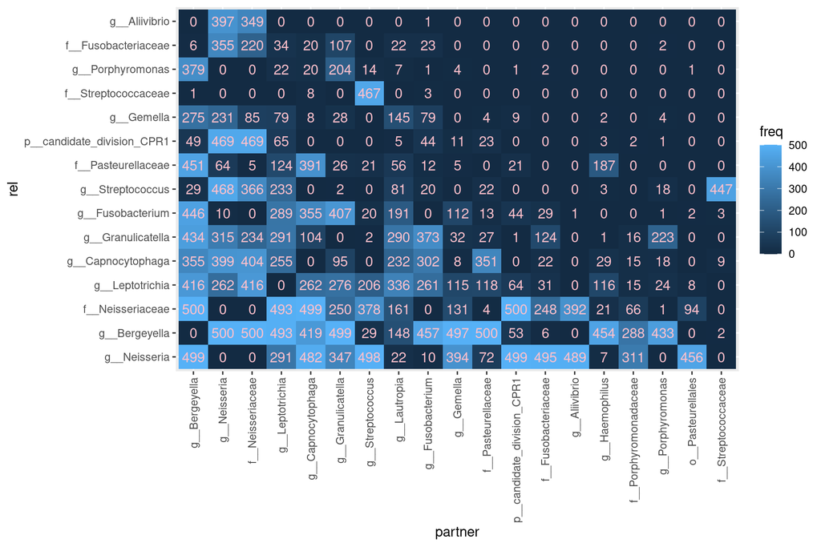

```r
vpm0<- partners_m0
colnames(vpm0)<- sapply(strsplit(colnames(tdata), "\\."), function(x) x[[length(x)]])
rownames(vpm0)<-sapply(strsplit(plausible, "\\."), function(x) x[[length(x)]])
vpm0<- vpm0[,order(colSums(vpm0),decreasing=TRUE)]
vpm0<- vpm0[order(rowSums(vpm0), decreasing = TRUE),]
vpm0<- vpm0[, colMaxs(vpm0)>300]
vpm0<- vpm0[rowMaxs(vpm0)>200 , ]
vpm0_flat<-melt(vpm0)
colnames(vpm0_flat)<-c("rel","partner","freq")
ggplot(vpm0_flat, aes(x=partner,y=rel,fill=freq))+ geom_tile()+
  theme(axis.text.x = element_text(angle = 90, vjust = 0.5, hjust = 1))+
    geom_text(aes(label = freq), color = "pink")
```

###### jackknife estimates of statistics: IG, presence, abundance

```r
jackknife_SE<- function(replicates,N,D,R=NULL){
  if (is.null(R)) R= N/D
  mean_rep= mean(replicates)
  sqrt((R/length(replicates))*sum((replicates-mean_rep)^2))
}
```

```r
for (v in names(global_MDFS))
  names(global_MDFS[[v]]$statistic)<- global_MDFS[[v]]$feature_names
fs_df<- data.frame(taxon=plausible,
                        IG2D= pmax(global_MDFS$res_2Dm$statistic[ plausible  ],
                                   global_MDFS$res_2D0$statistic[ plausible  ]),
                        IG2D_SD= apply(IG2D,2,jackknife_SE, nrow(taxonomy.mean.final), 0.37*nrow(taxonomy.mean.final) ),
                        IG1D= pmax(global_MDFS$res_1Dm$statistic[ plausible  ],
                                   global_MDFS$res_1D0$statistic[ plausible  ]),
                        IG1D_SD=apply(IG1D,2,jackknife_SE, nrow(taxonomy.mean.final), 0.37*nrow(taxonomy.mean.final)),
                        rel_1D= features_AP_filtered90["md1D",],
                        rel_2D= colSums(rel_2D),
                        rel_u=  features_AP_filtered90["u",]
                        )

viz_fs_df<- fs_df
rownames(viz_fs_df)<-NULL
viz_fs_df$taxon<-sapply(strsplit(fs_df$taxon,"\\."), function(x) x[[length(x)]])
viz_fs_df[,2:5]<- round(viz_fs_df[,2:5],2)
viz_fs_df[order(-viz_fs_df$IG2D) , ]
```

```
                        taxon   IG2D IG2D_SD   IG1D IG1D_SD rel_1D rel_2D rel_u
27               g__Neisseria 171.70   17.08 132.90   15.45    500    500   500
31             g__Pseudomonas 119.23   14.45 106.56   13.84    500    500   500
26           f__Neisseriaceae 104.29   13.61  64.60   11.00    500    500   500
14          g__Staphylococcus  72.39   11.35  64.77   11.03    500    500   500
16        f__Streptococcaceae  71.72   11.93  48.74    9.90    500    500   500
5            g__Cutibacterium  69.13   10.55  57.77   10.11    500    500   500
11        g__Chryseobacterium  55.22   10.04  47.41    9.83    500    499   499
3               g__Lawsonella  50.63    8.17  31.28    7.77    490    499   461
4       f__Corynebacteriaceae  49.28    9.13  38.27    8.71    499    498   442
8         f__Chitinophagaceae  46.21    8.64  37.69    8.16    498    487   489
33             g__Xanthomonas  43.52    7.84  36.79    7.39    499    495   497
20           g__Fusobacterium  43.27    8.26  15.84    5.48    159    482    16
17           g__Streptococcus  43.23    8.54   9.92    3.91     48    469     1
9               g__Bergeyella  41.50    7.23   0.99    1.58      0    500     0
```

[output cut: 20 more lines]

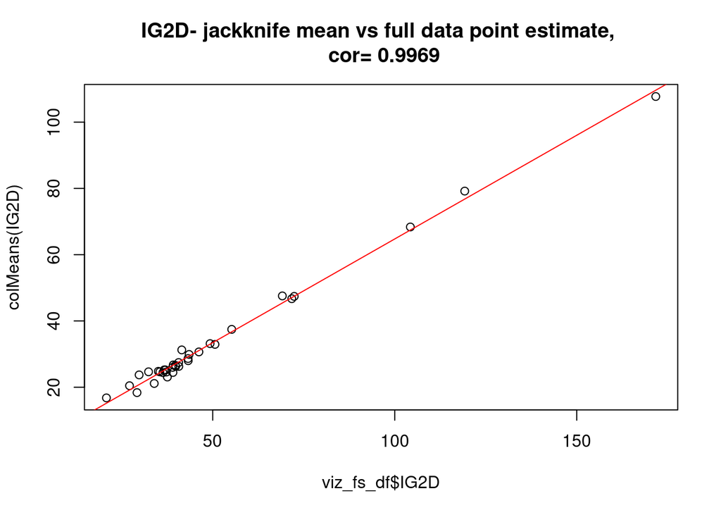

```r
plot(viz_fs_df$IG2D,colMeans(IG2D),
     main=sprintf("IG2D- jackknife mean vs full data point estimate, \n cor= %.4f",
                  cor(viz_fs_df$IG2D,colMeans(IG2D))
                  )
)
abline(lm(colMeans(IG2D)~viz_fs_df$IG2D), col="red")
```

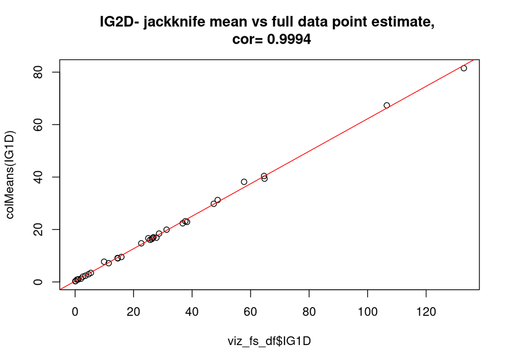

```r
plot(viz_fs_df$IG1D,colMeans(IG1D), main=sprintf("IG2D- jackknife mean vs full data point estimate, \n cor= %.4f",
                  cor(viz_fs_df$IG1D,colMeans(IG1D)) ))
abline(lm(colMeans(IG1D)~viz_fs_df$IG1D), col="red")
```

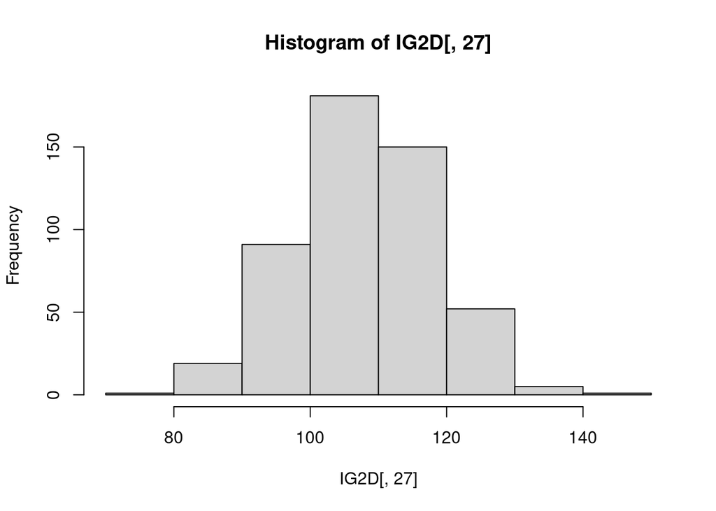

```r
hist(IG2D[,27])
```

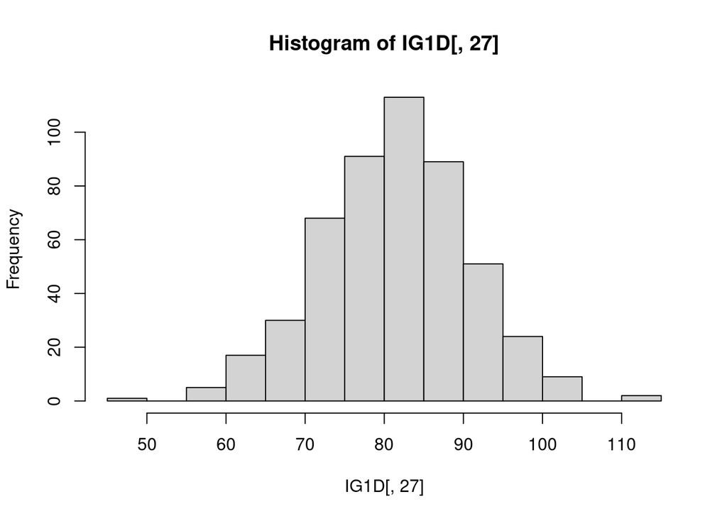

```r
hist(IG1D[,27])
```

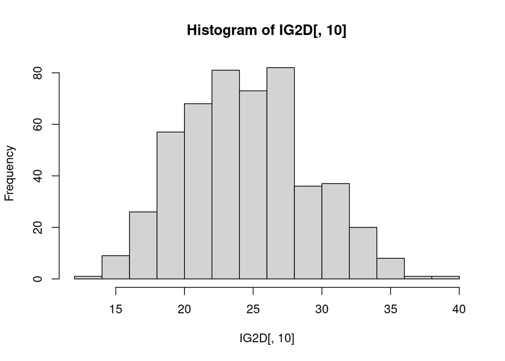

```r
hist(IG2D[,10])
```

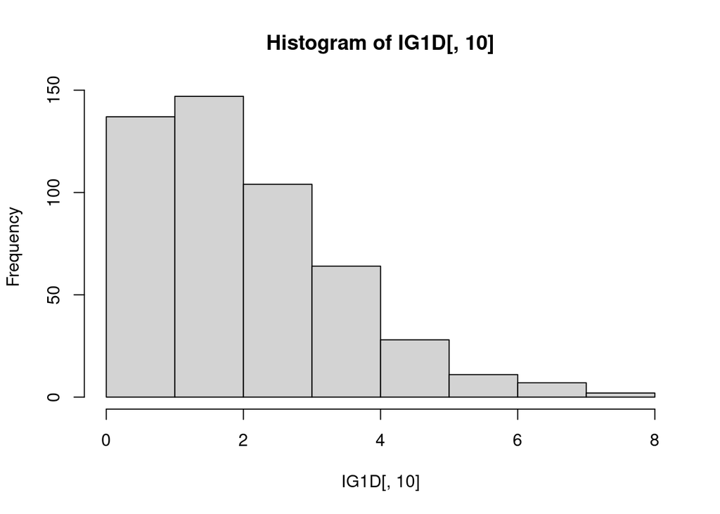

```r
hist(IG1D[,10])
```

```r
ses<-list(
se100=apply(IG2D[1:100,],2,jackknife_SE, nrow(taxonomy.mean.final), 0.37*nrow(taxonomy.mean.final) ),
se200=apply(IG2D[1:200,],2,jackknife_SE, nrow(taxonomy.mean.final), 0.37*nrow(taxonomy.mean.final) ),
se300=apply(IG2D[1:300,],2,jackknife_SE, nrow(taxonomy.mean.final), 0.37*nrow(taxonomy.mean.final) ),
se400=apply(IG2D[1:400,],2,jackknife_SE, nrow(taxonomy.mean.final), 0.37*nrow(taxonomy.mean.final) ),
se500=apply(IG2D[1:500,],2,jackknife_SE, nrow(taxonomy.mean.final), 0.37*nrow(taxonomy.mean.final) )
)
```

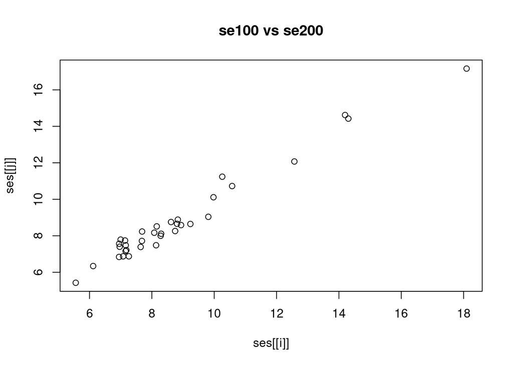

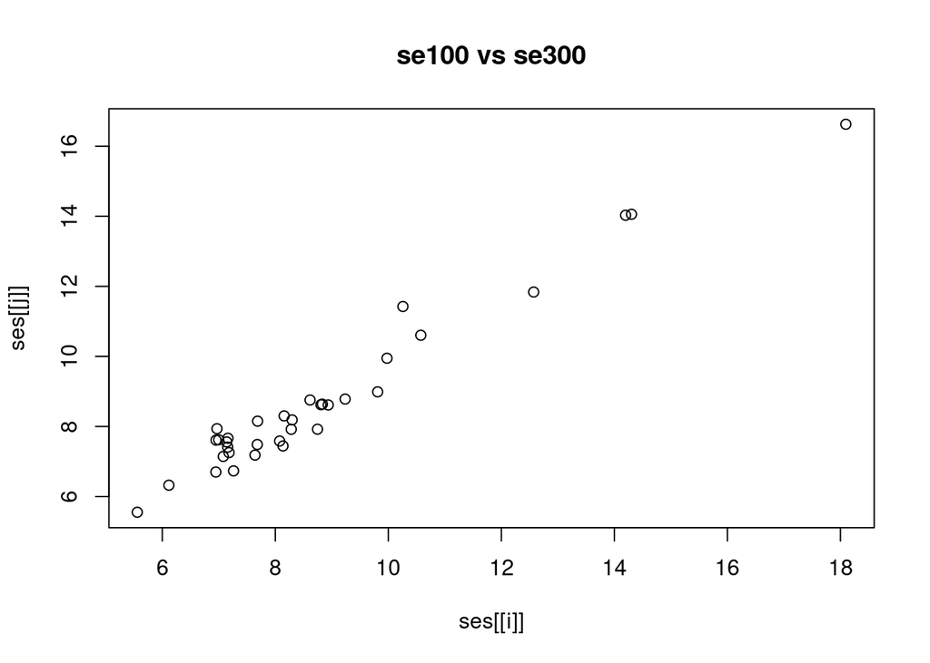

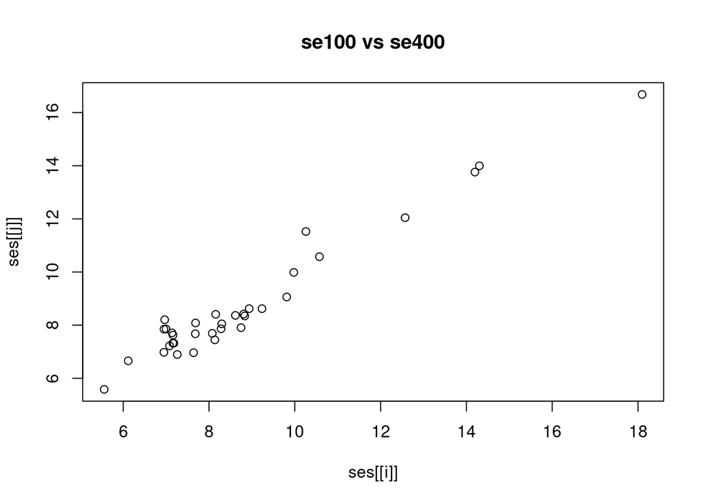

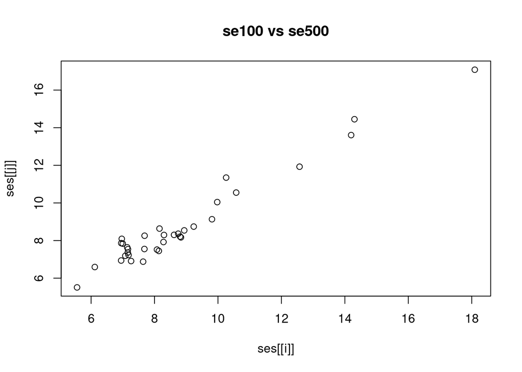

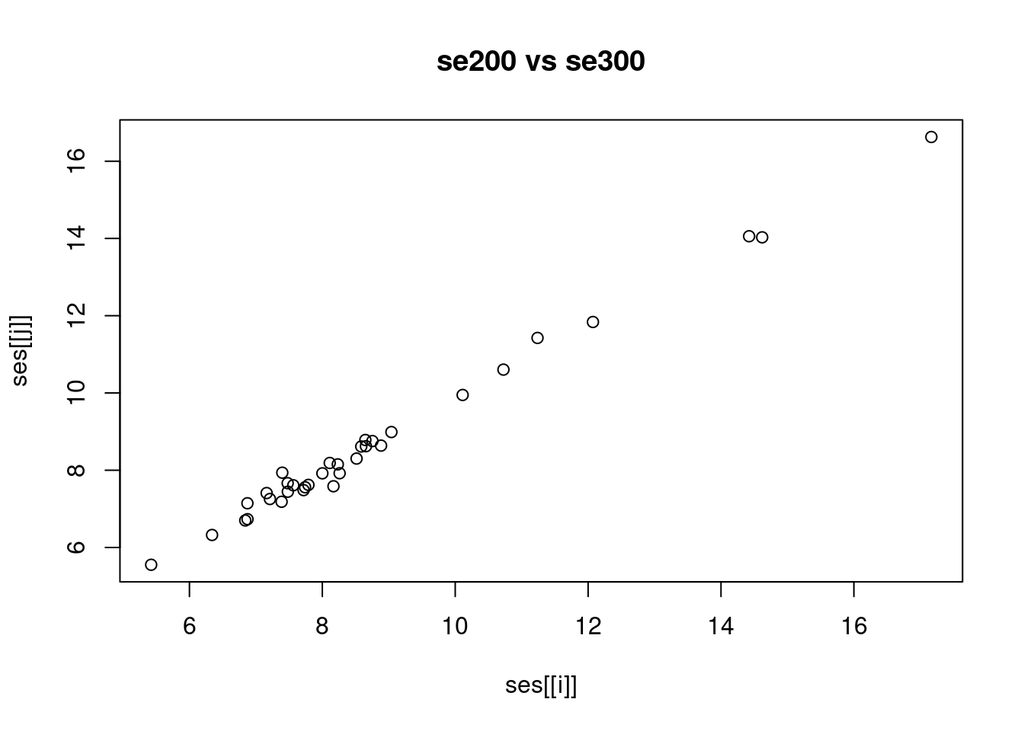

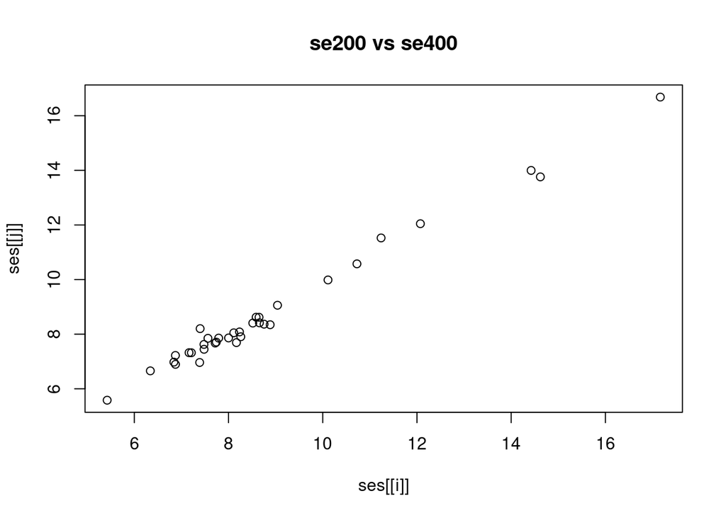

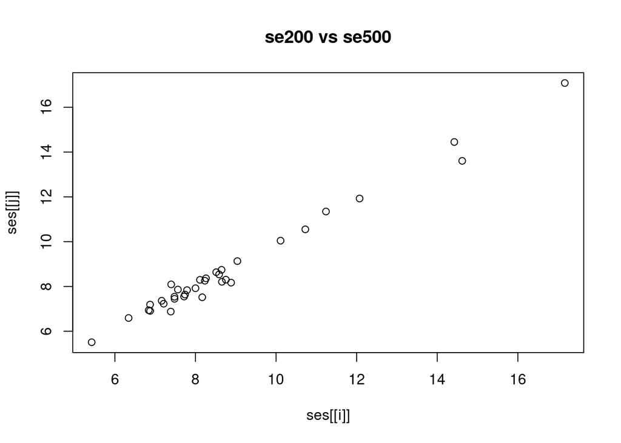

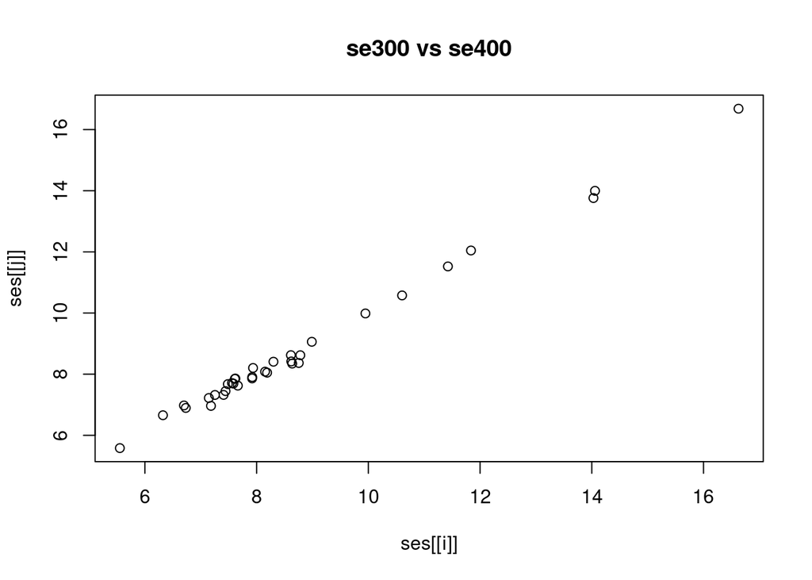

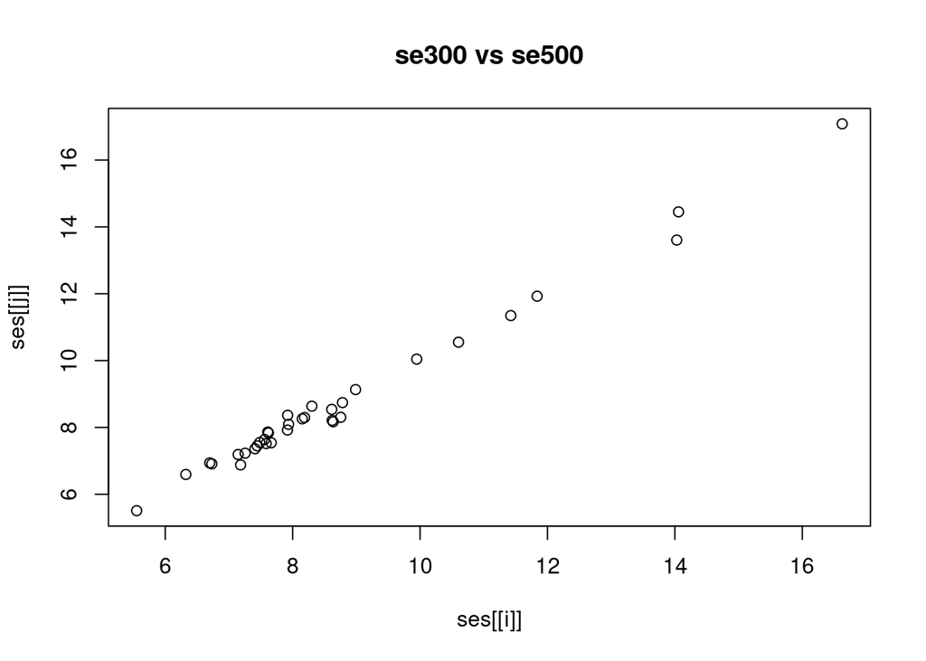

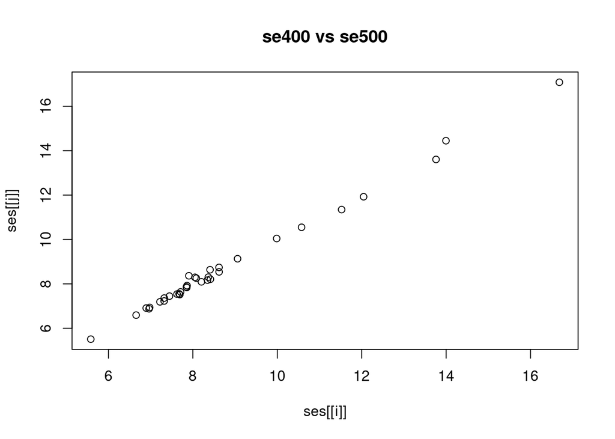

```r
for (i in seq_along(ses))
  for (j in seq_along(ses))
    if (i<j)
      plot(ses[[i]],ses[[j]], main=sprintf("%s vs %s", names(ses)[[i]], names(ses)[[j]] ))
```

```r
taxonomy.mean.final<- taxonomy.mean.final/10000
pab_df<- data.frame(taxon=plausible,
                        ab= colMeans(taxonomy.mean.final[,plausible]),
                        ab_SD= apply(abundance_per_rep,2,jackknife_SE, nrow(taxonomy.mean.final), 0.37* nrow(taxonomy.mean.final) ),
                        abH= colMeans(taxonomy.mean.final[ decision.mean.final==0 ,plausible]),
                        abH_SD= apply(abundance_per_repH,2,jackknife_SE, sum(decision.mean.final==0),
                                      0.37*sum(decision.mean.final==0)),
                        abD= colMeans(taxonomy.mean.final[ decision.mean.final==1 ,plausible]),
                        abD_SD= apply(abundance_per_repH,2,jackknife_SE, sum(decision.mean.final==1),
                                      0.37*sum(decision.mean.final==1)),
                        pr=colMeans(presence_0),
                        pr_SD=apply(presence_0,2, jackknife_SE, nrow(taxonomy.mean.final),
                                    0.37*nrow(taxonomy.mean.final)),
                        prH=colMeans(presence_0H),
                        prH_SD=apply(presence_0H,2,jackknife_SE, sum(decision.mean.final==0),
                                      0.37*sum(decision.mean.final==0)),
                        prD=colMeans(presence_0D),
                        prD_SD=apply(presence_0D,2,jackknife_SE, sum(decision.mean.final==1),
                                      0.37*sum(decision.mean.final==1))
                        )

viz_pab_df<- pab_df
rownames(viz_pab_df)<-NULL
viz_pab_df$taxon<-sapply(strsplit(pab_df$taxon,"\\."), function(x) x[[length(x)]])
viz_pab_df[, grep("ab",colnames(viz_pab_df))]<-10000*viz_pab_df[, grep("ab",colnames(viz_pab_df))]
viz_pab_df[,2:ncol(viz_pab_df)]<- round(viz_pab_df[,2:ncol(viz_pab_df)],2)
viz_pab_df[order(-viz_fs_df$IG2D) , ]
```

```
                        taxon    ab ab_SD    abH abH_SD   abD abD_SD   pr pr_SD
27               g__Neisseria  3.54  1.33   4.79   2.32  2.46   2.32 0.38  0.01
31             g__Pseudomonas 65.46  6.78  59.01  10.45 71.05  10.45 0.64  0.01
26           f__Neisseriaceae  0.37  0.08   0.30   0.08  0.44   0.08 0.22  0.01
14          g__Staphylococcus  2.65  1.13   2.03   0.52  3.18   0.52 0.33  0.01
16        f__Streptococcaceae  9.52  0.96   8.24   1.37 10.64   1.37 0.77  0.01
5            g__Cutibacterium  0.19  0.13   0.07   0.03  0.29   0.03 0.08  0.01
11        g__Chryseobacterium  1.64  0.64   1.36   0.71  1.88   0.71 0.09  0.01
3               g__Lawsonella  0.59  0.07   0.49   0.10  0.67   0.10 0.19  0.01
4       f__Corynebacteriaceae 10.88  3.30  10.93   6.51 10.83   6.51 0.51  0.01
8         f__Chitinophagaceae  0.09  0.04   0.06   0.06  0.11   0.06 0.05  0.00
33             g__Xanthomonas  0.25  0.08   0.02   0.01  0.44   0.01 0.03  0.00
20           g__Fusobacterium  6.80  1.70   6.62   2.06  6.96   2.06 0.35  0.01
17           g__Streptococcus 32.06  5.02  42.93   8.92 22.64   8.92 0.92  0.01
9               g__Bergeyella  0.21  0.05   0.30   0.09  0.14   0.09 0.10  0.01
```

[output cut: 55 more lines]

```r
write.csv(
cbind( viz_fs_df[order(-viz_fs_df$IG2D),],
       viz_pab_df[order(-viz_fs_df$IG2D) , 2:ncol(viz_pab_df) ]),
file="agp_data_per_taxa.csv")
```

##### MDFS 3D test

```r
MDFS3D<- readRDS("agp_result_3D.rds")
```

All confirmed taxa in 2D appear in 3D:

```r
i=1;j=1;
setSim=matrix(nrow=2,ncol=2)
for (set1 in list(
union(MDFS3D$median$rel_set, MDFS3D$zero$rel_set),
fs_df$taxon) ){for (set2 in list(
  union(MDFS3D$median$rel_set, MDFS3D$zero$rel_set),
fs_df$taxon
)){
      setSim[i,j]= length(intersect(set1,set2))
      j=j+1;
};i=i+1; j=1}

setSim
```

```
     [,1] [,2]
[1,]   70   34
[2,]   34   34
```

```r
print("Maximum IG of 3D vars NOT in set of taxa selected at least 90% of times:")
```

```
[1] "Maximum IG of 3D vars NOT in set of taxa selected at least 90% of times:"
```

```r
 setdiff( union(MDFS3D$median$rel_set, MDFS3D$zero$rel_set), fs_df$taxon)-> only3D
max(
c(
 mapply(function(mdfs, restriction){
    mdfs$statistic[ mdfs$feature_names %in% restriction ]
 }, MDFS3D, list(only3D, only3D))
) |> unlist()
)
```

```
[1] 47.6062
```

```r
IG3D_med= data.frame(taxon= MDFS3D$median$feature_names,
                     statisitc=MDFS3D$median$statistic)
IG3D_zero= data.frame(taxon= MDFS3D$zero$feature_names,
                     statisitc=MDFS3D$zero$statistic)
IG3D_med<- IG3D_med[ IG3D_med$taxon %in% fs_df$taxon,  ]
IG3D_zero<- IG3D_zero[ IG3D_zero$taxon %in% fs_df$taxon,  ]

stopifnot(all(IG3D_med$taxon == IG3D_zero$taxon))

data.frame(taxon=viz_fs_df$taxon,
           IG3D= pmax(IG3D_med$statisitc, IG3D_zero$statisitc),
           IG2D= viz_fs_df$IG2D

           )-> IG2Dv3D

IG2Dv3D$IG_increase= IG2Dv3D$IG3D - IG2Dv3D$IG2D

IG2Dv3D[order(-IG2Dv3D$IG_increase),]
```

```
                        taxon      IG3D   IG2D IG_increase
17           g__Streptococcus  72.11890  43.23   28.888896
9               g__Bergeyella  70.27905  41.50   28.779053
29         f__Pasteurellaceae  59.40601  39.01   20.396006
1       f__Bifidobacteriaceae  49.86133  29.79   20.071328
10          g__Capnocytophaga  54.98315  36.33   18.653154
31             g__Pseudomonas 137.75024 119.23   18.520244
26           f__Neisseriaceae 118.96924 104.29   14.679238
21            g__Leptotrichia  49.88623  35.48   14.406230
16        f__Streptococcaceae  84.92529  71.72   13.205293
22       f__Sphingomonadaceae  48.11011  35.06   13.050107
6  s__Collinsella_aerofaciens  51.90234  39.16   12.742344
5            g__Cutibacterium  81.68433  69.13   12.554326
34 p__candidate_division_CPR1  53.05371  40.64   12.413711
15          g__Granulicatella  52.36011  40.69   11.670107
```

[output cut: 20 more lines]

```r
print(as.matrix(IG2Dv3D[order(-IG2Dv3D$IG_increase),]))
```

```
   taxon                        IG3D        IG2D     IG_increase
17 "g__Streptococcus"           " 72.11890" " 43.23" "28.888896"
9  "g__Bergeyella"              " 70.27905" " 41.50" "28.779053"
29 "f__Pasteurellaceae"         " 59.40601" " 39.01" "20.396006"
1  "f__Bifidobacteriaceae"      " 49.86133" " 29.79" "20.071328"
10 "g__Capnocytophaga"          " 54.98315" " 36.33" "18.653154"
31 "g__Pseudomonas"             "137.75024" "119.23" "18.520244"
26 "f__Neisseriaceae"           "118.96924" "104.29" "14.679238"
21 "g__Leptotrichia"            " 49.88623" " 35.48" "14.406230"
16 "f__Streptococcaceae"        " 84.92529" " 71.72" "13.205293"
22 "f__Sphingomonadaceae"       " 48.11011" " 35.06" "13.050107"
6  "s__Collinsella_aerofaciens" " 51.90234" " 39.16" "12.742344"
5  "g__Cutibacterium"           " 81.68433" " 69.13" "12.554326"
34 "p__candidate_division_CPR1" " 53.05371" " 40.64" "12.413711"
15 "g__Granulicatella"          " 52.36011" " 40.69" "11.670107"
```

[output cut: 20 more lines]

```r
min(MDFS3D$median$statistic[MDFS3D$median$relevant.variables])
```

```
[1] 31.69531
```

```r
min(MDFS3D$zero$statistic[MDFS3D$zero$relevant.variables])
```

```
[1] 31.35986
```

##### Permutation test

Performed by `permutation_test.R` script - same basic steps of repeated subsampling 500 times and feature selection, but with decision labels permuted each time before sampling happens. This allows us to assess, independently of our testing method, the false positive rate of feature selection for all of the tested methods.

```r
n_perm<-500

perm_subsample<-readRDS('agp_subsamples63_perm.rds')
lop= 0.37 #leave out percentage
perm_features<- list(md1D=list(),
                md12D=list(),
                md12Dp=list(),
                u=list()
                )

perm_fs_j_pattern="features/perm_agp_fs_set_j=%d_lop=%.2f.rds"
 perm_full_MDFSres<- perm_full_Ures<-list()
for (j in 1:n_perm){
  fs_j_fname= sprintf(perm_fs_j_pattern,j,lop)
  stopifnot(file.exists(fs_j_fname))
        fs_j=readRDS(fs_j_fname)
        all_mdfs_j=fs_j$mdfs
        u_j=fs_j$u
  perm_full_MDFSres[[j]]=all_mdfs_j
  perm_full_Ures[[j]]=u_j
  perm_features$u[[j]]=u_j$rel_set
  perm_features$md1D[[j]]=union(all_mdfs_j$res_1Dm$rel_set, all_mdfs_j$res_1D0$rel_set)
  perm_features$md12D[[j]]=Reduce(union, list(all_mdfs_j$res_2Dm$rel_set,
                    all_mdfs_j$res_2D0$rel_set,
                    perm_features$md1D[[j]]))
  perm_features$md12Dp[[j]]=Reduce(union, list(all_mdfs_j$res_2Dm$partner_set,
                    all_mdfs_j$res_2D0$partner_set,
                    perm_features$md12D[[j]]))
}
```

```r
for (x in perm_full_MDFSres)
    print(x$res_1D0$statistic[ grep("g__Neisseria$",x$res_1D0$feature_names) ]==
        x$res_1Dm$statistic[ grep("g__Neisseria$",x$res_1Dm$feature_names) ])
```

```
[1] TRUE
[1] TRUE
[1] TRUE
[1] TRUE
[1] TRUE
[1] TRUE
[1] TRUE
[1] TRUE
[1] TRUE
[1] TRUE
[1] TRUE
[1] TRUE
[1] TRUE
[1] TRUE
[1] TRUE
```

[output cut: 485 more lines]

```r
someidx<-30
print(sprintf("some real example: "))
```

```
[1] "some real example: "
```

```r
table(y_real=y[ subsample[[someidx]]$keep ])
```

```
y_real
   0    1
1049 1263
```

```r
tmptaxa<- tdata
colnames(tmptaxa)<- sapply(strsplit(colnames(tmptaxa),"\\."), function(x) x[[length(x)]])

print(as.data.frame(do.call(table,c(
    binarize_taxa(tmptaxa[subsample[[someidx]]$keep,
                    grep(c("g__Neisseria$|g__Bergeyella$"), colnames(tmptaxa))],
    thresholds=rep(0,2)) |> as.data.frame() |> as.list(),
 list( y_real=y[ subsample[[someidx]]$keep ]) )
)))
```

```
  g__Bergeyella g__Neisseria y_real Freq
1             0            0      0  761
2             1            0      0    5
3             0            1      0  181
4             1            1      0  102
5             0            0      1  671
6             1            0      1    3
7             0            1      1  472
8             1            1      1  117
```

```r
set.seed(212)
for (someidx in sample(1:500,5,replace=FALSE)){
    print(sprintf("permutation #%d :", someidx))
yp<- y
yp[] <- y [ perm_subsample[[someidx]]$p_idx ]
print(table(y_permuted=yp[ perm_subsample[[someidx]]$keep ]))
print("y_permuted vs y:")
print(table(y_real=y[ subsample[[someidx]]$keep ] , y_permuted=yp[ perm_subsample[[someidx]]$keep ] ))
print(as.data.frame(do.call(table,c(
    binarize_taxa(tmptaxa[perm_subsample[[someidx]]$keep,
                    grep(c("g__Neisseria$|g__Bergeyella$"), colnames(tmptaxa))],
    thresholds=rep(0,2)) |> as.data.frame() |> as.list(),
 list( y_permuted=yp[ perm_subsample[[someidx]]$keep ]) )
)))
}
```

```
[1] "permutation #462 :"
y_permuted
   0    1
1011 1301
[1] "y_permuted vs y:"
      y_permuted
y_real   0   1
     0 470 592
     1 541 709
  g__Bergeyella g__Neisseria y_permuted Freq
1             0            0          0  630
2             1            0          0    8
3             0            1          0  289
4             1            1          0   84
5             0            0          1  777
```

[output cut: 75 more lines]

```r
someidx<-30
print(sprintf("some real example: "))
```

```
[1] "some real example: "
```

```r
table(y_real=y[ subsample[[someidx]]$keep ])
```

```
y_real
   0    1
1049 1263
```

```r
tmptaxa<- tdata
colnames(tmptaxa)<- sapply(strsplit(colnames(tmptaxa),"\\."), function(x) x[[length(x)]])

print(as.data.frame(do.call(table,c(
    binarize_taxa(tmptaxa[subsample[[someidx]]$keep,
                    grep(c("g__Neisseria$|g__Bergeyella$"), colnames(tmptaxa))],
    thresholds=colMedians(tmptaxa[subsample[[someidx]]$keep,
                    grep(c("g__Neisseria$|g__Bergeyella$"), colnames(tmptaxa))] |> as.matrix()
                  )) |> as.data.frame() |> as.list(),
 list( y_real=y[ subsample[[someidx]]$keep ]) )
)))
```

```
  g__Bergeyella g__Neisseria y_real Freq
1             0            0      0  761
2             1            0      0    5
3             0            1      0  181
4             1            1      0  102
5             0            0      1  671
6             1            0      1    3
7             0            1      1  472
8             1            1      1  117
```

```r
print(sprintf("IG({Y, Berg}+={Neiss})=%.3f", full_MDFSres[[someidx]]$res_2Dm$statistic[
                        grep("g__Neisseria$",full_MDFSres[[someidx]]$res_2Dm$feature_names)
                            ] ))
```

```
[1] "IG({Y, Berg}+={Neiss})=94.585"
```

```r
print(ComputeMaxInfoGainsDiscrete(data=binarize_taxa(tmptaxa[subsample[[someidx]]$keep,],
    thresholds=colMedians(tmptaxa[subsample[[someidx]]$keep,
                  ] |> as.matrix()
                         )), decision=yp[ subsample[[someidx]]$keep], dimensions=2)[
        grep("g__Neisseria$", colnames(tmptaxa)),
])
```

```
[1] 10.61011
```

```r
set.seed(212)
for (someidx in sample(1:500,5,replace=FALSE)){
    print(sprintf("permutation #%d :", someidx))
yp<- y
yp[] <- y [ perm_subsample[[someidx]]$p_idx ]
print(table(y_permuted=yp[ perm_subsample[[someidx]]$keep ]))
print("y_permuted vs y:")
print(table(y_real=y[ subsample[[someidx]]$keep ] , y_permuted=yp[ perm_subsample[[someidx]]$keep ] ))
print(as.data.frame(do.call(table,c(
    binarize_taxa(tmptaxa[perm_subsample[[someidx]]$keep,
                    grep(c("g__Neisseria$|g__Bergeyella$"), colnames(tmptaxa))],
    thresholds=colMedians(tmptaxa[perm_subsample[[someidx]]$keep,
                  grep(c("g__Neisseria$|g__Bergeyella$"),colnames(tmptaxa))] |> as.matrix()
                         ))|> as.data.frame() |> as.list(),
 list( y_permuted=yp[ perm_subsample[[someidx]]$keep ]) )
)))
print(sprintf("IG({Y, Berg}+={Neiss})=%.3f", perm_full_MDFSres[[someidx]]$res_2Dm$statistic[
                        grep("g__Neisseria$",perm_full_MDFSres[[someidx]]$res_2Dm$feature_names)
                            ] ))
print(ComputeMaxInfoGainsDiscrete(data=binarize_taxa(tmptaxa[perm_subsample[[someidx]]$keep,],
    thresholds=colMedians(tmptaxa[perm_subsample[[someidx]]$keep,
                  ] |> as.matrix()
                         )), decision=yp[ perm_subsample[[someidx]]$keep], dimensions=2)[
        grep("g__Neisseria$", colnames(tmptaxa)),
])
}
```

```
[1] "permutation #462 :"
y_permuted
   0    1
1011 1301
[1] "y_permuted vs y:"
      y_permuted
y_real   0   1
     0 470 592
     1 541 709
  g__Bergeyella g__Neisseria y_permuted Freq
1             0            0          0  630
2             1            0          0    8
3             0            1          0  289
4             1            1          0   84
5             0            0          1  777
```

[output cut: 85 more lines]

```r
eFPR<- list(md1D0=vector(),
     md1Dm=vector(),
     md2Dm=vector(),
     md2D0=vector(),
     u=vector())
for (j in 1:n_perm) {
eFPR[['md1D0']][[j]]=length(perm_full_MDFSres[[j]]$res_1D0$rel_set)/length(perm_full_MDFSres[[j]]$res_1D0$feature_names)
eFPR[['md1Dm']][[j]]=length(perm_full_MDFSres[[j]]$res_1Dm$rel_set)/length(perm_full_MDFSres[[j]]$res_1Dm$feature_names)
eFPR[['md2D0']][[j]]=length(perm_full_MDFSres[[j]]$res_2D0$rel_set)/length(perm_full_MDFSres[[j]]$res_2D0$feature_names)
eFPR[['md2Dm']][[j]]=length(perm_full_MDFSres[[j]]$res_2Dm$rel_set)/length(perm_full_MDFSres[[j]]$res_2Dm$feature_names)
eFPR[['u']][[j]]=length(perm_full_Ures[[j]]$rel_set)/length(perm_full_MDFSres[[j]]$res_1D0$feature_names) #same filtering on sparsity in U_test
}
```

```r
pdf("empirical_FPR.pdf")
for (name in names(eFPR))
hist(eFPR[[name]], main=name)
dev.off()
```

```r
max_permIG<- data.frame(IG1D= lapply(perm_full_MDFSres, function(x) max(max(x$res_1D0$statistic), max(x$res_1Dm$statistic)))|>unlist(),
                IG2D= lapply(perm_full_MDFSres, function(x) max(max(x$res_2D0$statistic), max(x$res_2Dm$statistic)))|>unlist(),
            IG_increase= lapply(perm_full_MDFSres, function(x)
                         max(max(x$res_2Dm$statistic- x$res_1Dm$statistic),
                         max(x$res_2Dm$statistic- x$res_1Dm$statistic)
                            )
                        )|>unlist()
            )
```

```r
pdf("max_perm_IG.pdf")
for (name in names(max_permIG))
 hist(max_permIG[[name]],main=sprintf("maximum %s - distribution over permutations", name))
dev.off()
```

```r
Reduce(rbind,
       lapply(perm_subsample, function(x)
x$p_idx  )
       )-> permutations
permutations<- as.data.frame(permutations)
nrow(permutations[!duplicated(permutations),])
```

```
[1] 500
```

```r
named_IG<- function(mdfs_result){
 ig<-mdfs_result$statistic
 names(ig)<-mdfs_result$feature_names
}
nS_gt_thr<- function(thr, S){
 length(S) - findInterval(sort(thr),sort(S))
}
mean_subsampleIG1D<-colMeans(IG1D)
mean_subsampleIG2D<-colMeans(IG2D)
meanIG1Dorder<-order(mean_subsampleIG1D)
meanIG2Dorder<-order(mean_subsampleIG2D)
n_perm_gt_IG1D0<-matrix(nrow=n_perm, ncol=length(mean_subsampleIG1D))
n_perm_gt_IG1Dm<-matrix(nrow=n_perm, ncol=length(mean_subsampleIG1D))
n_perm_gt_IG2D0<-matrix(nrow=n_perm, ncol=length(mean_subsampleIG2D))
n_perm_gt_IG2Dm<-matrix(nrow=n_perm, ncol=length(mean_subsampleIG2D))
for (j in 1:n_perm){
 if (j%%50==0) message(sprintf("%d /%d",j,n_perm))
 n_perm_gt_IG1D0[j,]<- nS_gt_thr(thr=mean_subsampleIG1D, S=perm_full_MDFSres[[j]]$res_1D0$statistic)
 n_perm_gt_IG1Dm[j,]<- nS_gt_thr(thr=mean_subsampleIG1D, S=perm_full_MDFSres[[j]]$res_1Dm$statistic)
 n_perm_gt_IG2D0[j,]<- nS_gt_thr(thr=mean_subsampleIG2D, S=perm_full_MDFSres[[j]]$res_2D0$statistic)
 n_perm_gt_IG2Dm[j,]<- nS_gt_thr(thr=mean_subsampleIG2D, S=perm_full_MDFSres[[j]]$res_2Dm$statistic)
}
```

```
50 /500
```

```
100 /500
```

```
150 /500
```

```
200 /500
```

```
250 /500
```

```
300 /500
```

```
350 /500
```

```
400 /500
```

```
450 /500
```

```
500 /500
```

```r
plot_survival_function<- function( Y, #n_reps x length(x)
               x, critical_x, crit_x_annot=NULL,
               ...){
 m<- colMeans(Y)
 sd<- apply(Y,2,sd)
 upper<- m+ sd
 lower<- m - sd

 plot(x, m, type="b", lwd=2, col="black",
      ylim= range(Y),
      ...)
 polygon(c(x,rev(x)),
     c(upper,rev(lower)),
     border=NA, col=rgb(0,0,1,0.25))
 abline(v=critical_x, lwd=2, col="red")
 if (!is.null(crit_x_annot)) legend("topright", lwd=2, col="red", legend=crit_x_annot)
}
pdf("n_perm_IG_gt_threshold.pdf")
plot_survival_function( n_perm_gt_IG1D0, sort(mean_subsampleIG1D),
            critical_x= min(mean_subsampleIG1D[ fs_df$rel_1D >= 450 ]),
            crit_x_annot= 'min IG1D \n (confirmed)',
               log='x',
               main='# variables with perm_IG > IG[i] \n 1D0',
               xlab='IG[i] (jackknife mean of confirmed variable number i )',
               ylab='# perm_IG > IG[i]')

plot_survival_function( n_perm_gt_IG1Dm, sort(mean_subsampleIG1D), log='x',
            critical_x= min(mean_subsampleIG1D[ fs_df$rel_1D >= 450 ]),
            crit_x_annot= 'min IG1D \n (confirmed)',
               main='# variables with perm_IG > IG[i] \n 1Dm',
               xlab='IG[i] (jackknife mean of confirmed variable number i )',
               ylab='# perm_IG > IG[i]')

plot_survival_function( n_perm_gt_IG2D0, sort(mean_subsampleIG2D), log='x',
            critical_x= min(mean_subsampleIG2D[ fs_df$rel_2D >= 450 ]),
            crit_x_annot= 'min IG2D \n (confirmed)',
               main='# variables with perm_IG > IG[i] \n 2D0',
               xlab='IG[i] (jackknife mean of confirmed variable number i )',
               ylab='# perm_IG > IG[i]')

plot_survival_function( n_perm_gt_IG2Dm, sort(mean_subsampleIG2D), log='x',
            critical_x= min(mean_subsampleIG2D[ fs_df$rel_2D >= 450 ]),
            crit_x_annot= 'min IG2D \n (confirmed)',
               main='# variables with perm_IG > IG[i] \n 2Dm',
               xlab='IG[i] (jackknife mean of confirmed variable number i )',
               ylab='# perm_IG > IG[i]')
dev.off()
```

```r
c("res_1Dm", "res_2Dm", "res_1D0", "res_2D0")-> variant_names

perm_IGranks<- lapply(variant_names,
              function(vn){
                 lapply(perm_full_MDFSres, function(x)
                     data.frame(taxon=x[[vn]]$feature_names,
                       IG=x[[vn]]$statistic)
                     )
              })

names(perm_IGranks)<-variant_names
pdf("perm_IG_ranks.pdf")
for (vn in variant_names){
    plot(rank(perm_IGranks[[vn]][[1]]$IG),
         perm_IGranks[[vn]][[1]]$IG,
          pch=16, cex=0.3,col=rgb(0,0,0,0.3),
    main=sprintf("%s - distribution of k-th largest IG over permuations",vn),
    xlab="rank(IG_perm)", ylab="IG_perm")
    for (j in 2:length(perm_IGranks[[vn]]))
        points(rank(perm_IGranks[[vn]][[j]]$IG),
            perm_IGranks[[vn]][[j]]$IG,
          pch=16, cex=0.3, col=rgb(0,0,0,0.3))
    if (vn %in% c("res_2D0", "res_2Dm")){
    abline(h= min(mean_subsampleIG2D[ fs_df$rel_2D >= 450 ]), lwd=3,col="red")
    legend("topleft", lwd=3, col="red", legend="min 2D IG confirmed \n (jackknife mean)")
    } else {
    abline(h= min(mean_subsampleIG1D[ fs_df$rel_1D >= 450 ]), lwd=3,col="red")
    legend("topleft", lwd=3, col="red", legend="min 1D IG confirmed \n (jackknife mean)")
    }
}
dev.off()
```

```r
all_the_taxa_permTest<-Reduce(union,lapply(perm_IGranks, function(x) Reduce(union,lapply(x, function(y) y$taxon))))
```

```r
k=35
F<-lapply(variant_names, function(x) matrix(0, nrow=length(all_the_taxa_permTest),
       ncol=k))
names(F)<-variant_names
for (i in seq_along(F)) rownames(F[[i]])<-all_the_taxa_permTest
for (vn in variant_names) for (j in 1:n_perm){
    top_k_idx<- order(perm_IGranks[[vn]][[j]]$IG, decreasing=TRUE)[1:k]
    top_k_taxa<-perm_IGranks[[vn]][[j]]$taxon[top_k_idx]
    for (k_i in 1:k){
    F[[vn]][ top_k_taxa[[k_i]],k_i   ]=   F[[vn]][ top_k_taxa[[k_i]],k_i   ] + 1
    }
}
```

```r
vn<- variant_names[[1]]
pdf("rank_frequency_perm.pdf", width=14,height=7)
for (vn in variant_names){
F_v<-   F[[vn]][ order(-rowSums(F[[vn]])), ]
rownames(F_v)<- sapply(strsplit(rownames(F_v),"\\."), function(x) x[[length(x)]])
F_v<- F_v[1:35,1:10]
F_v_flat<-melt(F_v)
colnames(F_v_flat)<- c("taxon", "top_k","freq")
myplot<-ggplot(F_v_flat, aes(x= taxon, y=top_k, fill=freq)) + geom_tile()+
   ggtitle(sprintf("%s - frequency of having top_k highest IG in permuatations",vn))+
  theme(axis.text.x = element_text(angle = 90, vjust = 0.5, hjust = 1))+
    geom_text(aes(label = freq), color = "pink")
    #ggsave(sprintf("%s_rankFreq_perm.pdf",vn),myplot,width=14,height=7,units="in")
    print(myplot)
}
dev.off()
```

```r
plausible_perm_IG<- lapply(variant_names, function(vn)
              matrix(NA,nrow=n_perm, ncol=length(plausible)))
names(plausible_perm_IG)<- variant_names
for (vn in variant_names) colnames(plausible_perm_IG[[vn]])<- plausible
for (vn in variant_names) for (j in 1:n_perm){
    perm_IGranks[[vn]][[j]]$IG-> temp
    names(temp)<- perm_IGranks[[vn]][[j]]$taxon
    plausible_perm_IG[[vn]][j, ]= temp[ plausible ]
}
```

```r
for (vn in variant_names) colnames(plausible_perm_IG[[vn]])<- sapply(strsplit(plausible,"\\."), function(x) x[[length(x)]])

pdf("IGperm_histograms_plausible.pdf")

for (ptaxa in colnames(plausible_perm_IG[[1]]))
    for (vn in variant_names)
        hist(plausible_perm_IG[[vn]][,ptaxa], main= sprintf("perm_IG of %s - %s", ptaxa, vn))

dev.off()
```